# 10 minites

##### Box-Cox Transformation to normality

- When the model violates the *normality* assumption, you typically attempt a transformation of the *response variable (Y-variable)*.
- When the assumption of *linearity* is violated, a transformation of the *predictor variables (X-Variables)* can often help.

  Our model seems to violate the assumption of *normality*, so we would try to transform *response variable (“price” in our case)*

```r
#let's filter out price=0 and calculate the power
library(tidyverse)
airbnb2_filtered_price <- airbnb2%>%
  filter(price > 0) %>%
  drop_na()


summary(powerTransform(airbnb2_filtered_price$price))
```

```
## bcPower Transformation to Normality
##                              Est Power Rounded Pwr Wald Lwr Bnd Wald Upr Bnd
## airbnb2_filtered_price$price    -0.241       -0.24      -0.2511       -0.231
##
## Likelihood ratio test that transformation parameter is equal to 0
##  (log transformation)
##                            LRT df       pval
## LR test, lambda = (0) 2392.175  1 < 2.22e-16
##
## Likelihood ratio test that no transformation is needed
##                            LRT df       pval
## LR test, lambda = (1) 111259.9  1 < 2.22e-16
```

Since “price” is highly skewed, we could try using log 10 transformation for it.

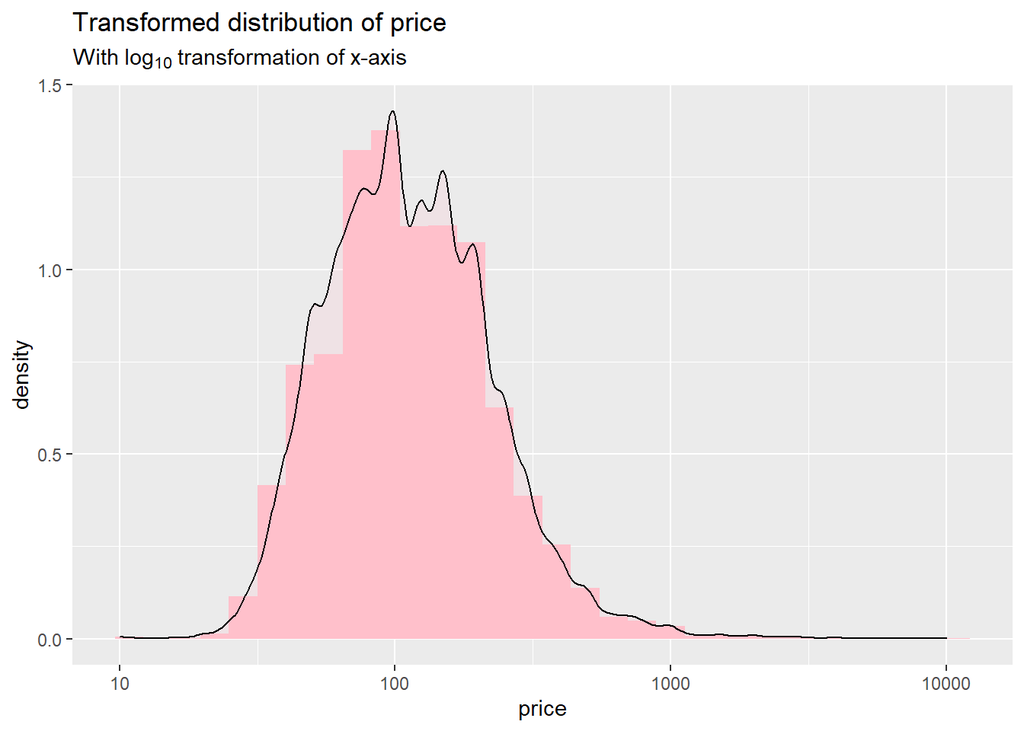

```r
library(ggplot2)
ggplot(airbnb2, aes(price)) +
  geom_histogram(bins = 30, aes(y = ..density..), fill = "pink") +
  geom_density(alpha = 0.2, fill = "pink") +ggtitle("Transformed distribution of price",
  subtitle = expression("With" ~'log'[10] ~ "transformation of x-axis")) + scale_x_log10()
```

It looks like “price” is more normally distributed than before.

The original distribution of “price” is highly skewed.

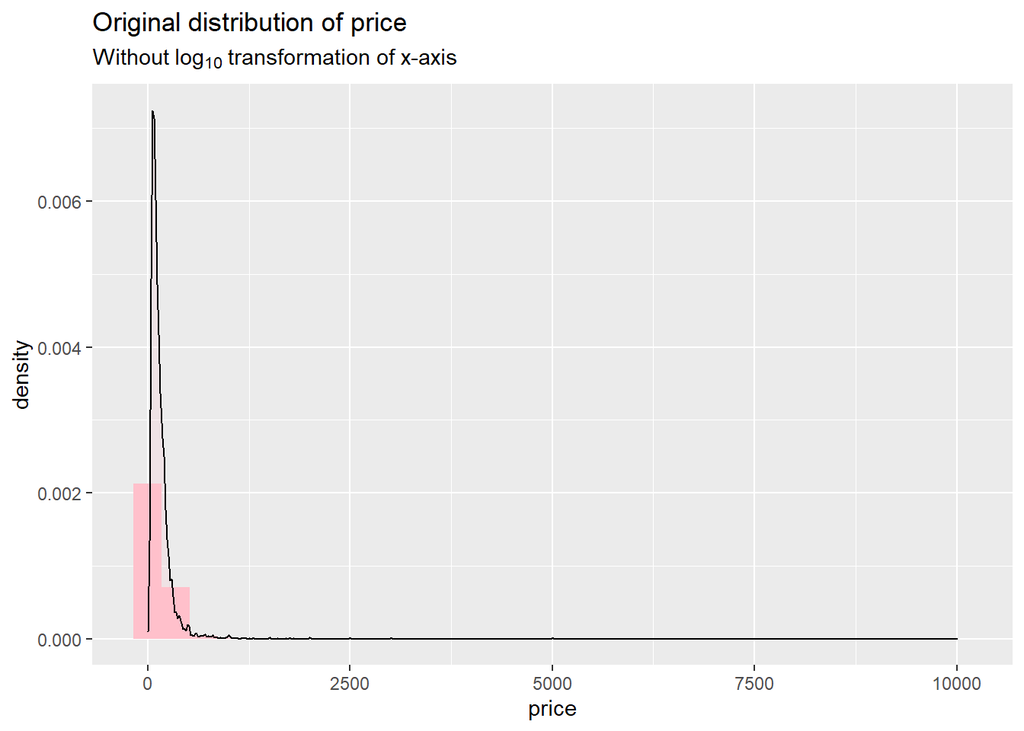

```r
# without log transformation
#library(ggplot2)
ggplot(airbnb2, aes(price)) +
  geom_histogram(bins = 30, aes(y = ..density..), fill = "pink") +
  geom_density(alpha = 0.2, fill = "pink") +ggtitle("Original distribution of price",
  subtitle = expression("Without" ~'log'[10] ~ "transformation of x-axis"))
```

Let’s try modeling it after log transformation.

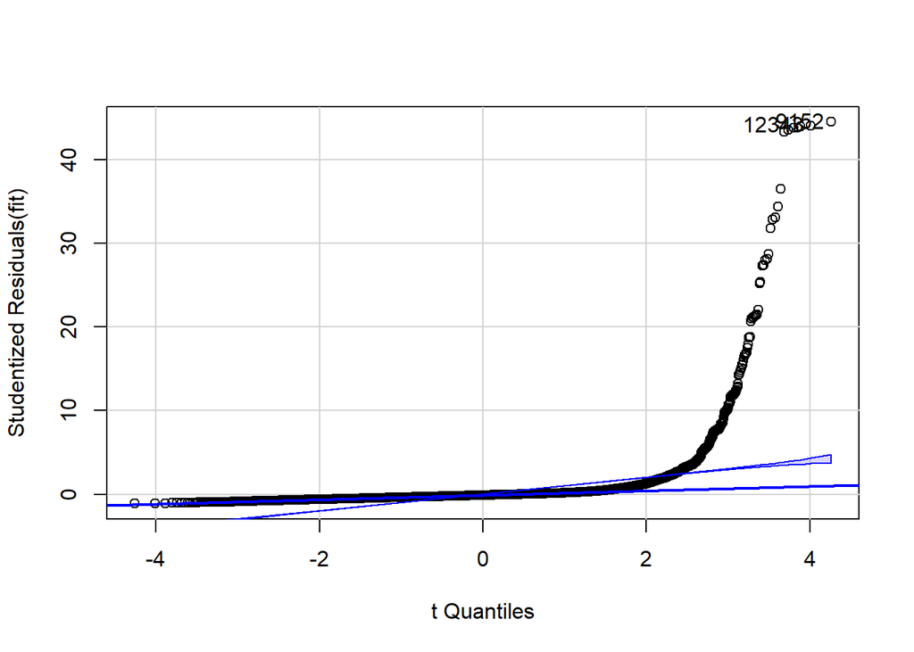

```
## [1]  9152 12343
```

```r
airbnb3 <- airbnb2 %>% filter(price > 0)
fit.tr<- lm(log10(price) ~., data=airbnb3)
qqPlot(fit) #just for comparison
```

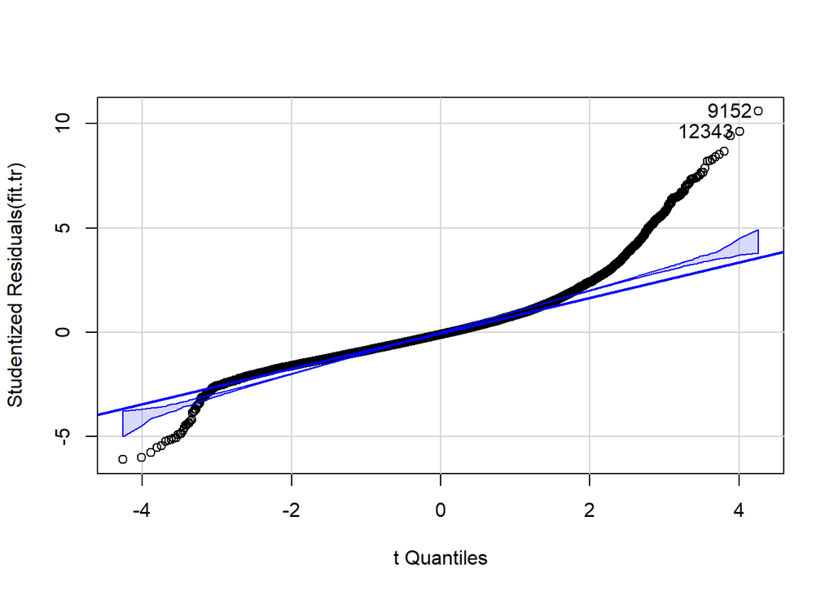

```
## [1]  9152 12343
```

```r
qqPlot(fit.tr)
```

It seems that the normality is better enhanced after transformation, especially in the middle part. But it still has two tails and also hard to interpret in terms of airbnb industry.

##### Global test of linear model assumptions after transformation

```r
library(gvlma)
gvmodel.tr <- gvlma(fit.tr)
summary(gvmodel.tr)
```

```
##
## Call:
## lm(formula = log10(price) ~ ., data = airbnb3)
##
## Residuals:
##      Min       1Q   Median       3Q      Max
## -1.31829 -0.13598 -0.02257  0.10353  2.28730
##
## Coefficients:
##                                    Estimate Std. Error  t value Pr(>|t|)
## (Intercept)                      -8.359e+01  3.037e+00  -27.521  < 2e-16 ***
## neighbourhood_groupBrooklyn      -1.727e-02  8.305e-03   -2.080   0.0375 *
## neighbourhood_groupManhattan      1.156e-01  7.541e-03   15.323  < 2e-16 ***
## neighbourhood_groupQueens         3.626e-02  8.006e-03    4.529 5.94e-06 ***
## neighbourhood_groupStaten Island -3.535e-01  1.579e-02  -22.391  < 2e-16 ***
## latitude                         -2.703e-01  2.964e-02   -9.121  < 2e-16 ***
## longitude                        -1.308e+00  3.404e-02  -38.425  < 2e-16 ***
## room_typePrivate room            -3.274e-01  2.043e-03 -160.235  < 2e-16 ***
## room_typeShared room             -5.040e-01  6.524e-03  -77.256  < 2e-16 ***
## minimum_nights                   -8.371e-04  4.873e-05  -17.177  < 2e-16 ***
## number_of_reviews                -3.233e-04  2.246e-05  -14.398  < 2e-16 ***
## availability_365                  3.253e-04  7.776e-06   41.840  < 2e-16 ***
## ---
## Signif. codes:  0 '***' 0.001 '**' 0.01 '*' 0.05 '.' 0.1 ' ' 1
##
## Residual standard error: 0.2162 on 48872 degrees of freedom
## Multiple R-squared:  0.4919, Adjusted R-squared:  0.4918
## F-statistic:  4301 on 11 and 48872 DF,  p-value: < 2.2e-16
##
##
## ASSESSMENT OF THE LINEAR MODEL ASSUMPTIONS
## USING THE GLOBAL TEST ON 4 DEGREES-OF-FREEDOM:
## Level of Significance =  0.05
##
## Call:
##  gvlma(x = fit.tr)
##
##                       Value  p-value                   Decision
## Global Stat        82340.32 0.00e+00 Assumptions NOT satisfied!
## Skewness           13941.04 0.00e+00 Assumptions NOT satisfied!
## Kurtosis           68208.23 0.00e+00 Assumptions NOT satisfied!
## Link Function        137.66 0.00e+00 Assumptions NOT satisfied!
## Heteroscedasticity    53.39 2.73e-13 Assumptions NOT satisfied!
```

The model still failed the global test.

Let’s identify mulicollinearity:

```r
fit <- lm(price ~., data=airbnb2)
vif(fit) # The R function vif() can be used to detect multicollinearity in a regression model. The rule of thumb: vif > 4 means presence of Multi-collinearity.
```

```
##                         GVIF Df GVIF^(1/(2*Df))
## neighbourhood_group 6.645084  4        1.267105
## latitude            2.732352  1        1.652983
## longitude           2.582937  1        1.607152
## room_type           1.068434  2        1.016686
## minimum_nights      1.045251  1        1.022375
## number_of_reviews   1.046967  1        1.023214
## availability_365    1.095779  1        1.046795
```

```r
max(vif(fit))
```

```
## [1] 6.645084
```

We see that the variable “neighbourhood_group” has the highest vif (6.645084). A vif value of more than 4 is considered high. Thus, let’s remove this variable and obtain the vifs again:

```r
fit1=lm(price ~.-neighbourhood_group, data=airbnb2)
# summary(lm.fit1)
vif(fit1)
```

```
##                       GVIF Df GVIF^(1/(2*Df))
## latitude          1.009009  1        1.004494
## longitude         1.059562  1        1.029350
## room_type         1.047681  2        1.011713
## minimum_nights    1.043803  1        1.021667
## number_of_reviews 1.045680  1        1.022585
## availability_365  1.070238  1        1.034523
```

```r
max(vif(fit1))
```

```
## [1] 2
```

Now, the vif of variables are all less than 4.

We can visualize interactions using the effect() function in the effects package.

```
## NOTE: neighbourhood_group:longitude does not appear in the model
```

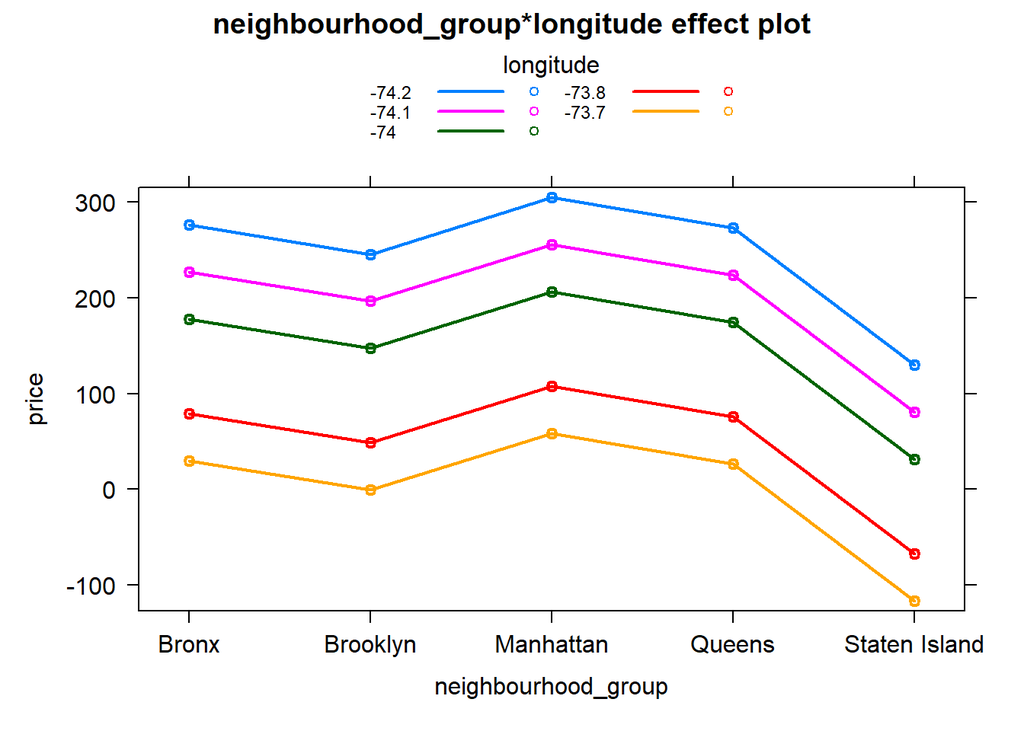

```r
#plotting the interaction effect
#ignore the warning in the following command.
library(car)
library(effects)
# ?effect #to learn more about the function
par(mfrow=c(2,2))
plot(effect("neighbourhood_group:longitude", fit,, list(wt=c(2.2, 3.2, 4.2))), multiline=TRUE)
```

```
## NOTE: neighbourhood_group:latitude does not appear in the model
```

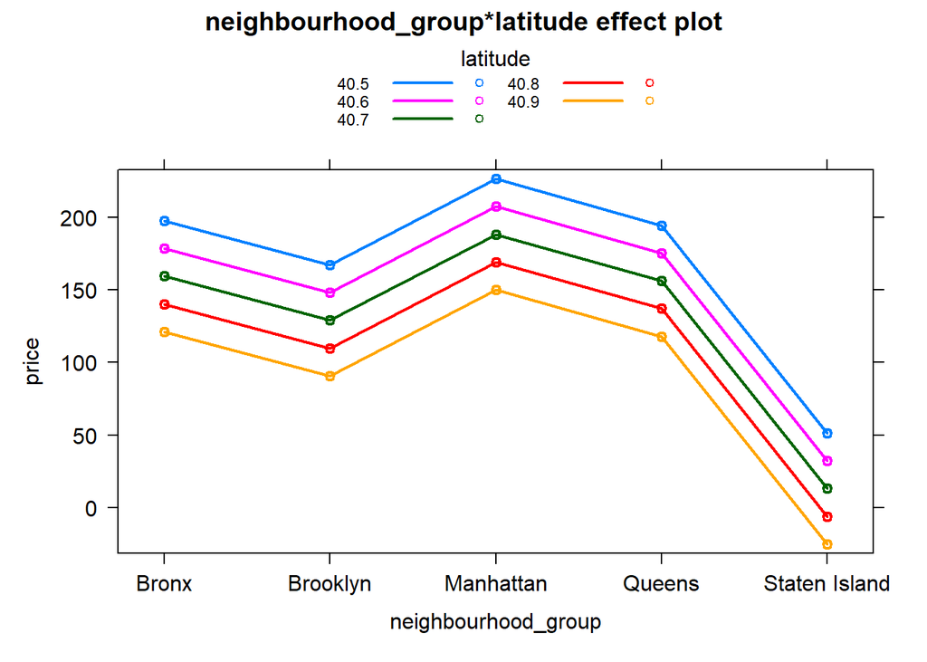

```r
plot(effect("neighbourhood_group:latitude", fit,, list(wt=c(2.2, 3.2, 4.2))), multiline=TRUE)
```

```
## NOTE: neighbourhood_group:room_type does not appear in the model
```

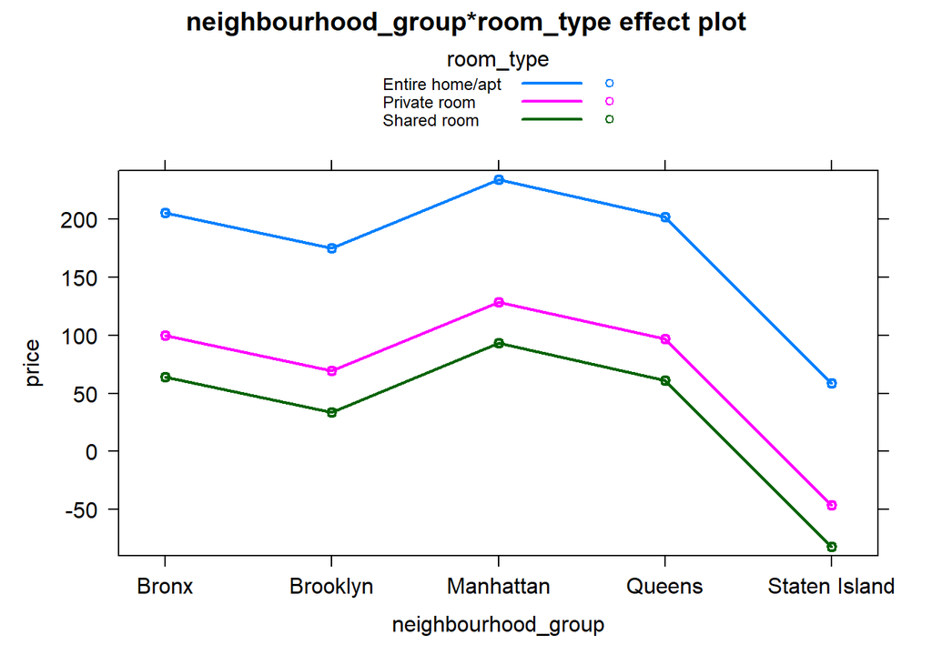

```r
plot(effect("neighbourhood_group:room_type ", fit,, list(wt=c(2.2, 3.2, 4.2))), multiline=TRUE)
```

```
## NOTE: neighbourhood_group:minimum_nights does not appear in the model
```

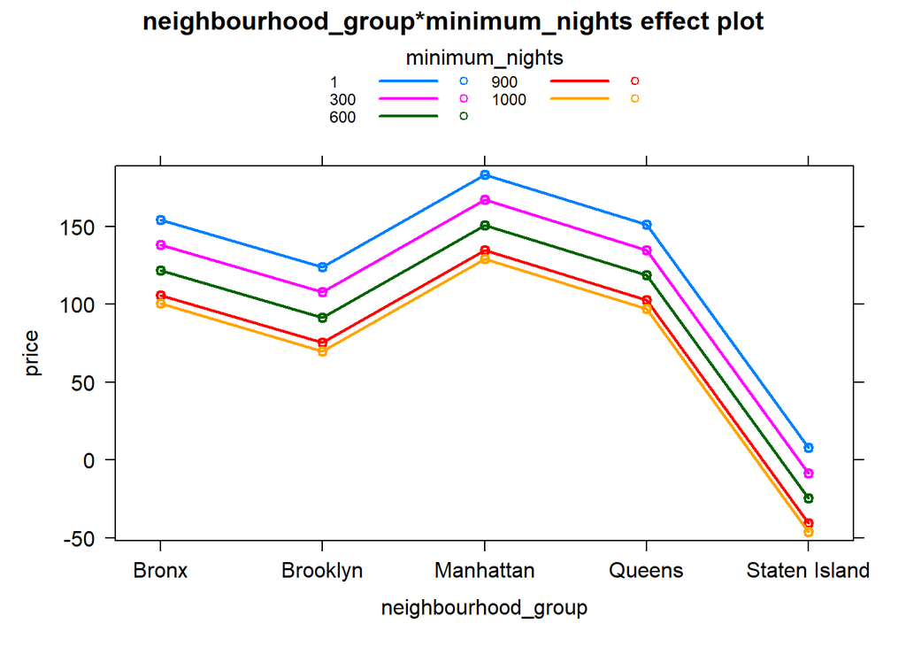

```r
plot(effect("neighbourhood_group:minimum_nights ", fit,, list(wt=c(2.2, 3.2, 4.2))), multiline=TRUE)
```

```
## NOTE: latitude:longitude does not appear in the model
```

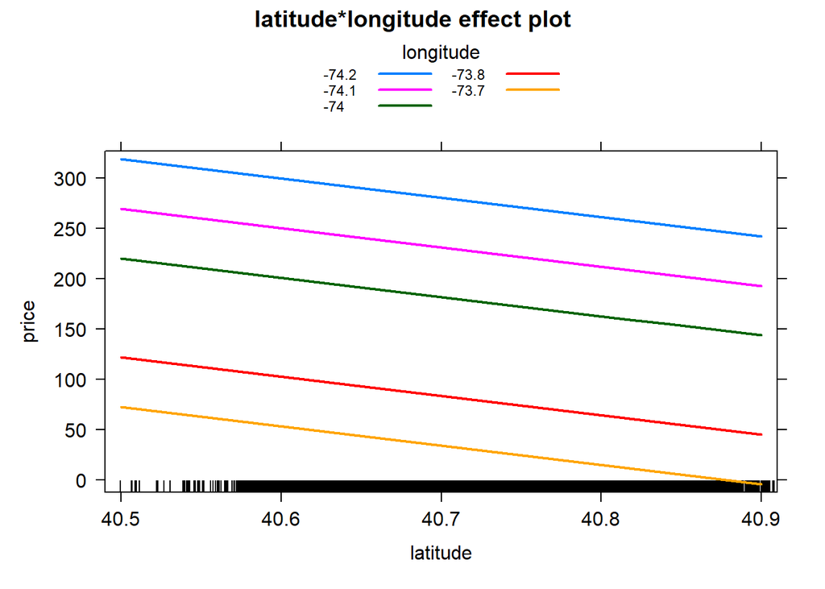

```r
par(mfrow=c(2,2))
plot(effect("latitude:longitude", fit,, list(wt=c(2.2, 3.2, 4.2))), multiline=TRUE)
```

```
## NOTE: longitude:room_type does not appear in the model
```

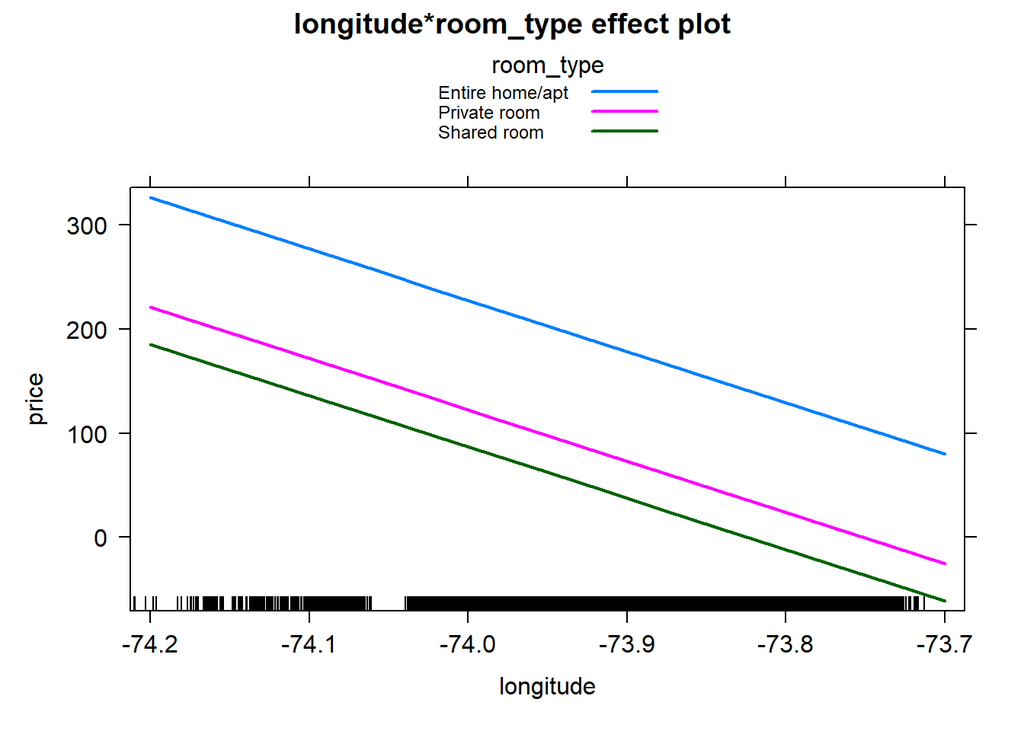

```r
plot(effect("longitude:room_type", fit,, list(wt=c(2.2, 3.2, 4.2))), multiline=TRUE)
```

```
## NOTE: latitude:room_type does not appear in the model
```

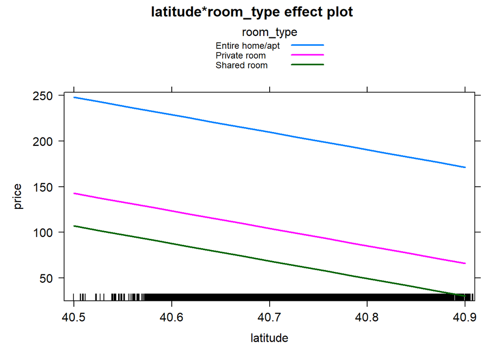

```r
plot(effect("latitude:room_type ", fit,, list(wt=c(2.2, 3.2, 4.2))), multiline=TRUE)
```

```
## NOTE: room_type:minimum_nights does not appear in the model
```

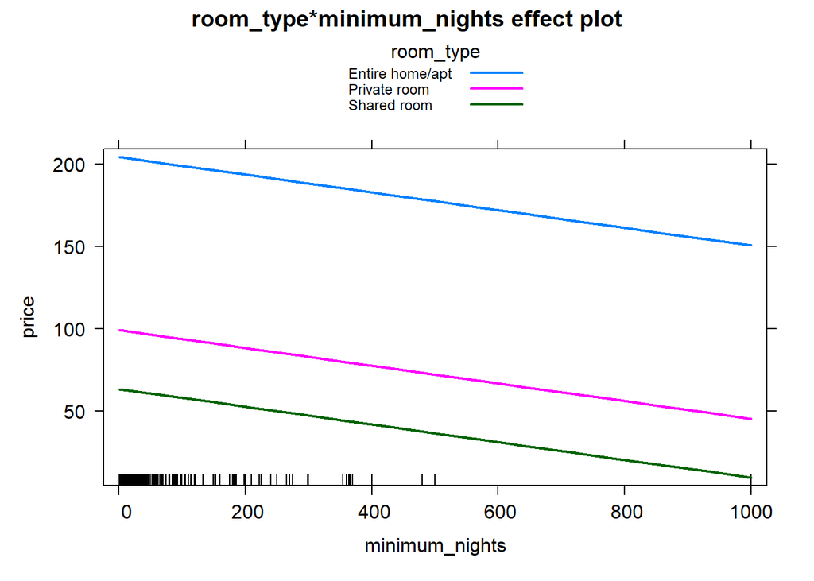

```r
plot(effect("room_type:minimum_nights ", fit,, list(wt=c(2.2, 3.2, 4.2))), multiline=TRUE)
```

```
## NOTE: room_type:number_of_reviews does not appear in the model
```

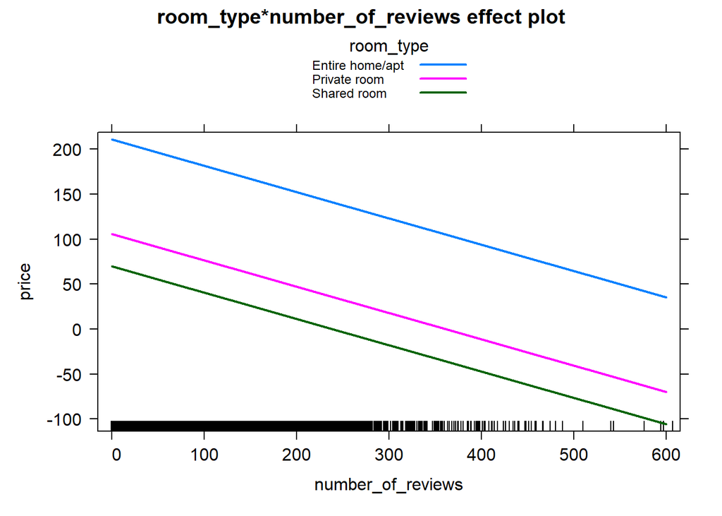

```r
par(mfrow=c(2,1))
plot(effect("room_type:number_of_reviews", fit,, list(wt=c(2.2, 3.2, 4.2))), multiline=TRUE)
```

```
## NOTE: latitude:minimum_nights does not appear in the model
```

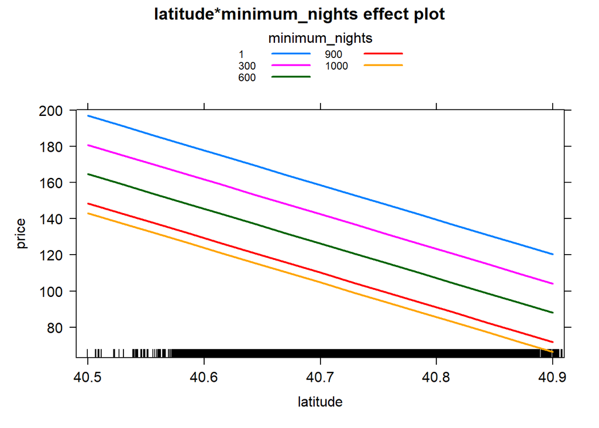

```r
plot(effect("latitude:minimum_nights ", fit,, list(wt=c(2.2, 3.2, 4.2))), multiline=TRUE)
```

We have not found any interactions among each two pairs of variables.

#### Linear regression for prediction, validation part

Partition data

```r
#training set will be 70% percent and testing data will be 30% of the original data.
set.seed(211)
train.index <- sample(c(1:dim(airbnb2)[1]), dim(airbnb2)[1]*0.7)
train <- airbnb2[train.index, ]
test <- airbnb2[-train.index, ]
```

Build the linear model

```r
linear<-lm(price~., data = train)
summary(linear)
```

```
##
## Call:
## lm(formula = price ~ ., data = train)
##
## Residuals:
##    Min     1Q Median     3Q    Max
## -256.7  -63.4  -24.4   15.3 9938.8
##
## Coefficients:
##                                    Estimate Std. Error t value Pr(>|t|)
## (Intercept)                      -2.724e+04  3.925e+03  -6.941 3.96e-12 ***
## neighbourhood_groupBrooklyn      -3.560e+01  1.066e+01  -3.340 0.000838 ***
## neighbourhood_groupManhattan      2.755e+01  9.672e+00   2.849 0.004391 **
## neighbourhood_groupQueens        -5.479e+00  1.029e+01  -0.532 0.594453
## neighbourhood_groupStaten Island -1.469e+02  2.072e+01  -7.088 1.39e-12 ***
## latitude                         -2.190e+02  3.830e+01  -5.718 1.09e-08 ***
## longitude                        -4.916e+02  4.401e+01 -11.171  < 2e-16 ***
## room_typePrivate room            -1.042e+02  2.643e+00 -39.432  < 2e-16 ***
## room_typeShared room             -1.398e+02  8.510e+00 -16.425  < 2e-16 ***
## minimum_nights                    3.598e-02  6.146e-02   0.585 0.558324
## number_of_reviews                -3.103e-01  2.897e-02 -10.712  < 2e-16 ***
## availability_365                  1.916e-01  1.006e-02  19.039  < 2e-16 ***
## ---
## Signif. codes:  0 '***' 0.001 '**' 0.01 '*' 0.05 '.' 0.1 ' ' 1
##
## Residual standard error: 233.9 on 34214 degrees of freedom
## Multiple R-squared:  0.09509,    Adjusted R-squared:  0.0948
## F-statistic: 326.9 on 11 and 34214 DF,  p-value: < 2.2e-16
```

Predict the model

```r
linear.pred<-predict(linear, test, type = 'response')
```

get the test error = Mean square error (MSE)

```r
mean((linear.pred-test$price)^2)
```

```
## [1] 45857.28
```

#### Subset selection

##### 1. Best subset selection

```r
#install.packages("leaps")
library(leaps)
fit.full=regsubsets(price~., data = train)

summary(fit.full)
```

```
## Subset selection object
## Call: regsubsets.formula(price ~ ., data = train)
## 11 Variables  (and intercept)
##                                  Forced in Forced out
## neighbourhood_groupBrooklyn          FALSE      FALSE
## neighbourhood_groupManhattan         FALSE      FALSE
## neighbourhood_groupQueens            FALSE      FALSE
## neighbourhood_groupStaten Island     FALSE      FALSE
## latitude                             FALSE      FALSE
## longitude                            FALSE      FALSE
## room_typePrivate room                FALSE      FALSE
## room_typeShared room                 FALSE      FALSE
## minimum_nights                       FALSE      FALSE
## number_of_reviews                    FALSE      FALSE
## availability_365                     FALSE      FALSE
## 1 subsets of each size up to 8
## Selection Algorithm: exhaustive
##          neighbourhood_groupBrooklyn neighbourhood_groupManhattan
## 1  ( 1 ) " "                         " "
## 2  ( 1 ) " "                         "*"
## 3  ( 1 ) " "                         "*"
## 4  ( 1 ) " "                         "*"
## 5  ( 1 ) " "                         "*"
## 6  ( 1 ) " "                         "*"
## 7  ( 1 ) " "                         "*"
## 8  ( 1 ) "*"                         " "
##          neighbourhood_groupQueens neighbourhood_groupStaten Island latitude
## 1  ( 1 ) " "                       " "                              " "
## 2  ( 1 ) " "                       " "                              " "
## 3  ( 1 ) " "                       " "                              " "
## 4  ( 1 ) " "                       " "                              " "
## 5  ( 1 ) " "                       " "                              " "
## 6  ( 1 ) " "                       " "                              " "
## 7  ( 1 ) " "                       "*"                              " "
## 8  ( 1 ) " "                       "*"                              "*"
##          longitude room_typePrivate room room_typeShared room minimum_nights
## 1  ( 1 ) " "       "*"                   " "                  " "
## 2  ( 1 ) " "       "*"                   " "                  " "
## 3  ( 1 ) " "       "*"                   " "                  " "
## 4  ( 1 ) " "       "*"                   "*"                  " "
## 5  ( 1 ) "*"       "*"                   "*"                  " "
## 6  ( 1 ) "*"       "*"                   "*"                  " "
## 7  ( 1 ) "*"       "*"                   "*"                  " "
## 8  ( 1 ) "*"       "*"                   "*"                  " "
##          number_of_reviews availability_365
## 1  ( 1 ) " "               " "
## 2  ( 1 ) " "               " "
## 3  ( 1 ) " "               "*"
## 4  ( 1 ) " "               "*"
## 5  ( 1 ) " "               "*"
## 6  ( 1 ) "*"               "*"
## 7  ( 1 ) "*"               "*"
## 8  ( 1 ) "*"               "*"
```

- An asterisk indicates that a given variable is included in the corresponding model.
- By default, regsubsets() only reports results up to the best eight-variable model.

  The *nvmax* option can be used in order to return as many variables as are desired. Here we fit up to a 7-variable model.

```r
regfit.full=regsubsets(price~., data = train,nvmax=7)
reg.summary=summary(regfit.full)
reg.summary
```

```
## Subset selection object
## Call: regsubsets.formula(price ~ ., data = train, nvmax = 7)
## 11 Variables  (and intercept)
##                                  Forced in Forced out
## neighbourhood_groupBrooklyn          FALSE      FALSE
## neighbourhood_groupManhattan         FALSE      FALSE
## neighbourhood_groupQueens            FALSE      FALSE
## neighbourhood_groupStaten Island     FALSE      FALSE
## latitude                             FALSE      FALSE
## longitude                            FALSE      FALSE
## room_typePrivate room                FALSE      FALSE
## room_typeShared room                 FALSE      FALSE
## minimum_nights                       FALSE      FALSE
## number_of_reviews                    FALSE      FALSE
## availability_365                     FALSE      FALSE
## 1 subsets of each size up to 7
## Selection Algorithm: exhaustive
##          neighbourhood_groupBrooklyn neighbourhood_groupManhattan
## 1  ( 1 ) " "                         " "
## 2  ( 1 ) " "                         "*"
## 3  ( 1 ) " "                         "*"
## 4  ( 1 ) " "                         "*"
## 5  ( 1 ) " "                         "*"
## 6  ( 1 ) " "                         "*"
## 7  ( 1 ) " "                         "*"
##          neighbourhood_groupQueens neighbourhood_groupStaten Island latitude
## 1  ( 1 ) " "                       " "                              " "
## 2  ( 1 ) " "                       " "                              " "
## 3  ( 1 ) " "                       " "                              " "
## 4  ( 1 ) " "                       " "                              " "
## 5  ( 1 ) " "                       " "                              " "
## 6  ( 1 ) " "                       " "                              " "
## 7  ( 1 ) " "                       "*"                              " "
##          longitude room_typePrivate room room_typeShared room minimum_nights
## 1  ( 1 ) " "       "*"                   " "                  " "
## 2  ( 1 ) " "       "*"                   " "                  " "
## 3  ( 1 ) " "       "*"                   " "                  " "
## 4  ( 1 ) " "       "*"                   "*"                  " "
## 5  ( 1 ) "*"       "*"                   "*"                  " "
## 6  ( 1 ) "*"       "*"                   "*"                  " "
## 7  ( 1 ) "*"       "*"                   "*"                  " "
##          number_of_reviews availability_365
## 1  ( 1 ) " "               " "
## 2  ( 1 ) " "               " "
## 3  ( 1 ) " "               "*"
## 4  ( 1 ) " "               "*"
## 5  ( 1 ) " "               "*"
## 6  ( 1 ) "*"               "*"
## 7  ( 1 ) "*"               "*"
```

```r
names(reg.summary)
```

```
## [1] "which"  "rsq"    "rss"    "adjr2"  "cp"     "bic"    "outmat" "obj"
```

Evaluating each model using R-Square

```r
reg.summary$rsq
```

```
## [1] 0.05487842 0.07116314 0.07817630 0.08556982 0.08956517 0.09282539 0.09364841
```

From above, we can see that by adding more variables we are able to increase RSQ. How many variables should we select? Let’s decide that using a plot:

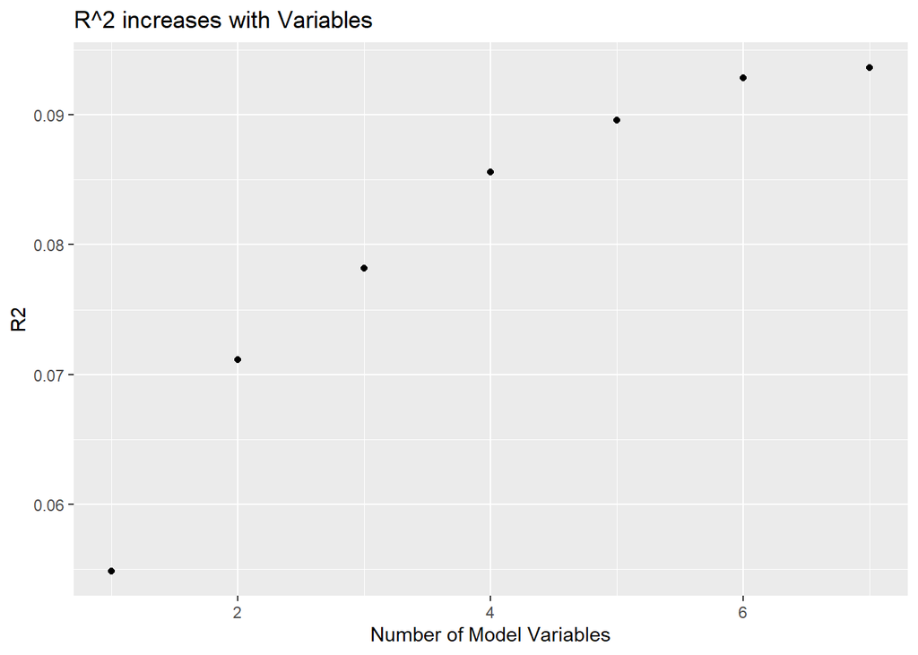

```r
RSQdata <- as.data.frame(reg.summary$rsq)
names(RSQdata)<-"R2" # Renaming the column as "R2"

# Plot
ggplot(RSQdata,aes(x = c(1:nrow(RSQdata)), y = R2)) +
  geom_point()+
  labs(x="Number of Model Variables")+
  labs(title="R^2 increases with Variables")
```

* Using the plot, we see that R-Squared doesn’t increase too much after 6 variables. Thus, selecting a 6-variable model may be good.

- There is a drawback with R-Squared. It continues to increase with the number of variables. We can instead use Adjusted R-Squared, which adjusts the value of R-Squared according to the number of variables uses (by penalizing for using more variables).

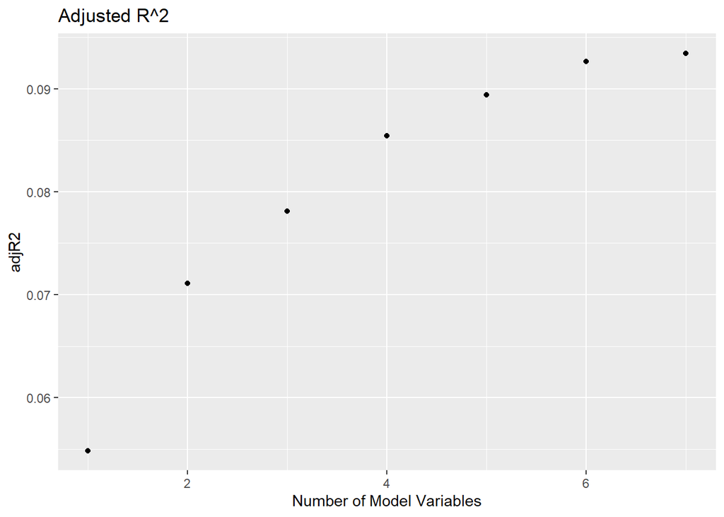

```r
adjRSQdata <- as.data.frame(reg.summary$adjr2)
names(adjRSQdata)<-"adjR2"
ggplot(adjRSQdata,aes(x = c(1:nrow(adjRSQdata)), y = adjR2)) +
  geom_point()+
  labs(x="Number of Model Variables")+
  labs(title="Adjusted R^2")
```

```r
which(max(adjRSQdata)==adjRSQdata) # Finding the number of variables where Adj-R-Squared is maximized
```

```
## [1] 7
```

We see that the Adj-Rsq are pretty much the same as Rsq plot. And it looks like including 6 variables are nearly the same as including 7 variables in terms of adjusted R^2.

Using residual sum of squares *RSS* for deciding number of variables (instead of R-Square or Adj-R-Squared):

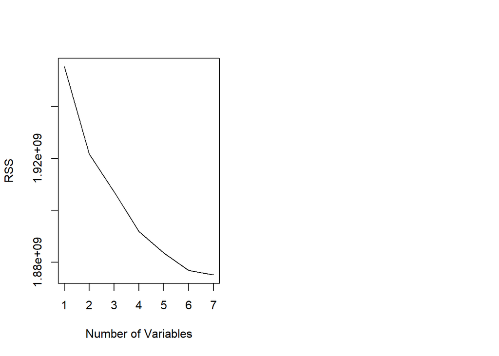

```r
par(mfrow=c(1,2))
plot(reg.summary$rss,xlab="Number of Variables",ylab="RSS",type="l")
# plot(reg.summary$adjr2,xlab="Number of Variables",ylab="Adjusted RSq",type="l")
# which.max(reg.summary$adjr2)
# Output of above: 11
# points(11,reg.summary$adjr2[11], col="red",cex=2,pch=20) # Show the maximum point
```

The RSS plot also indicates that 6 variables may be the most appropriate (because the error barely decrease after that).

- Similar to R-Squared, RSS also has a drawback that it continues to decrease with the number of variables. We can use “cp” to do this. Repeating above with a different criteria: cp (we should choose smallest cp)

```
## [1] 7
```

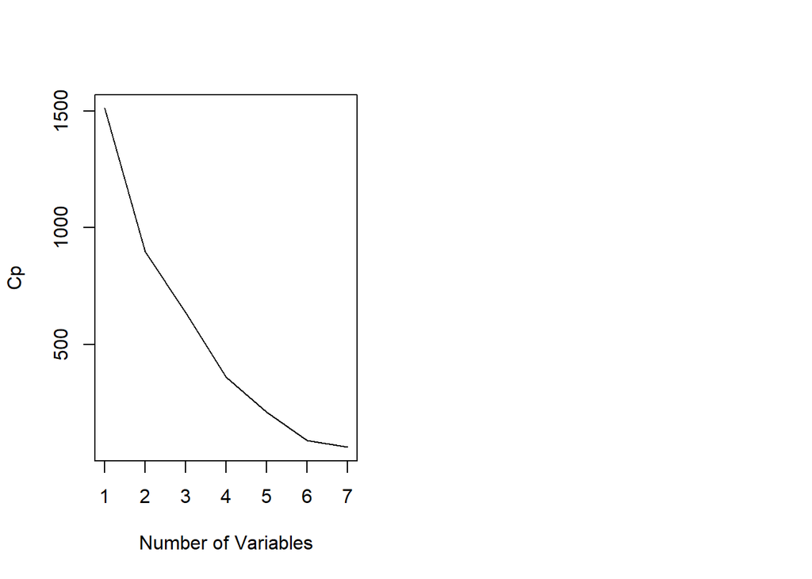

```r
par(mfrow=c(1,2))
plot(reg.summary$cp,xlab="Number of Variables",ylab="Cp",type='l')
points(10,reg.summary$cp[10],col="red",cex=2,pch=20)
which.min(reg.summary$cp)
```

# Using BIC (Bayesian information criterion): Choose the minimum

```r
which.min(reg.summary$bic)
```

```
## [1] 7
```

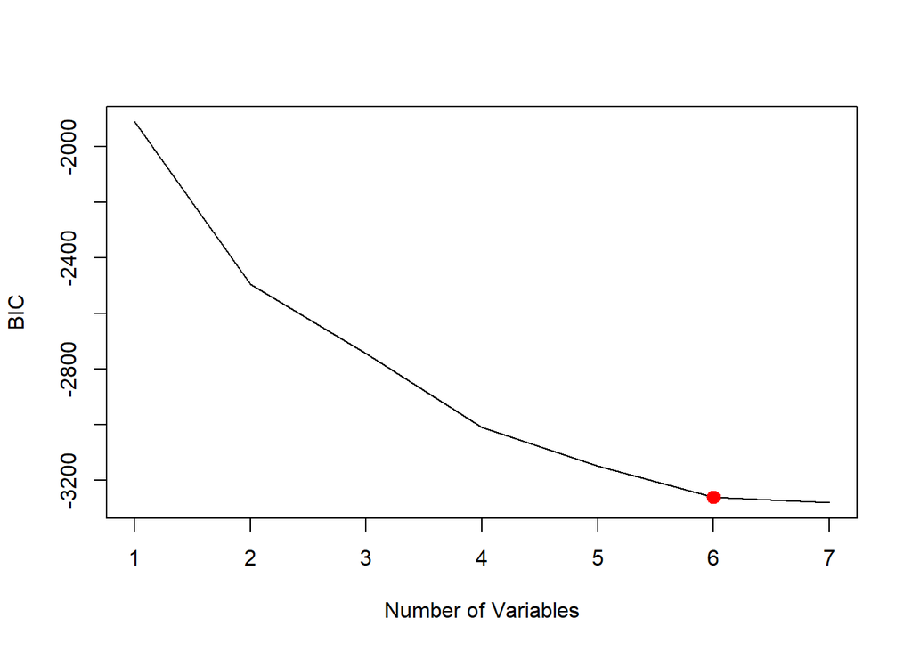

```r
plot(reg.summary$bic,xlab="Number of Variables",ylab="BIC",type='l')
points(6,reg.summary$bic[6],col="red",cex=2,pch=20)
```

The regsubsets() function has a built-in plot() command which can be used to display the selected variables for the best model with a given number of predictors, ranked according to the BIC, Cp, adjusted R2, or AIC.

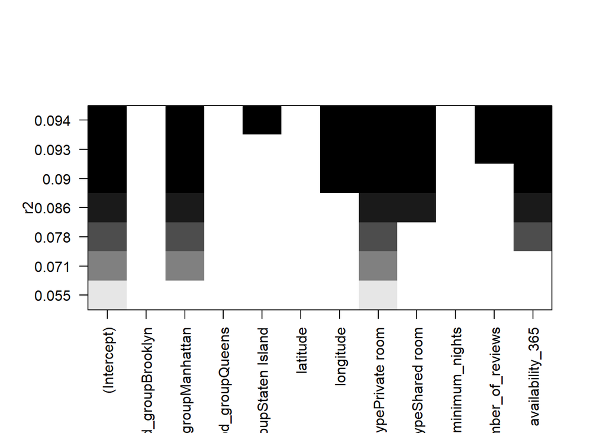

```r
plot(regfit.full,scale="r2")
```

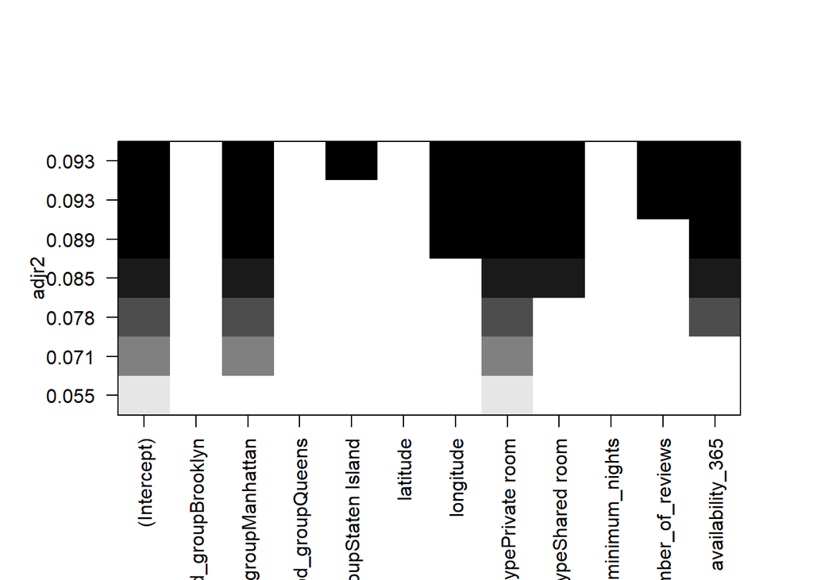

```r
plot(regfit.full,scale="adjr2")
```

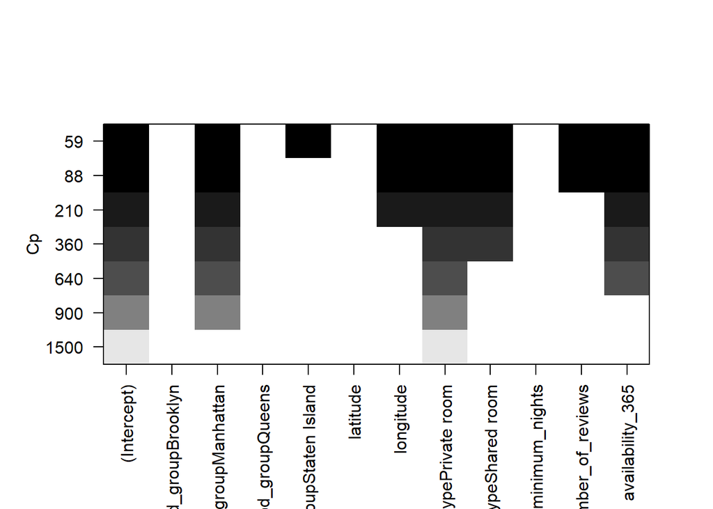

```r
plot(regfit.full,scale="Cp")
```

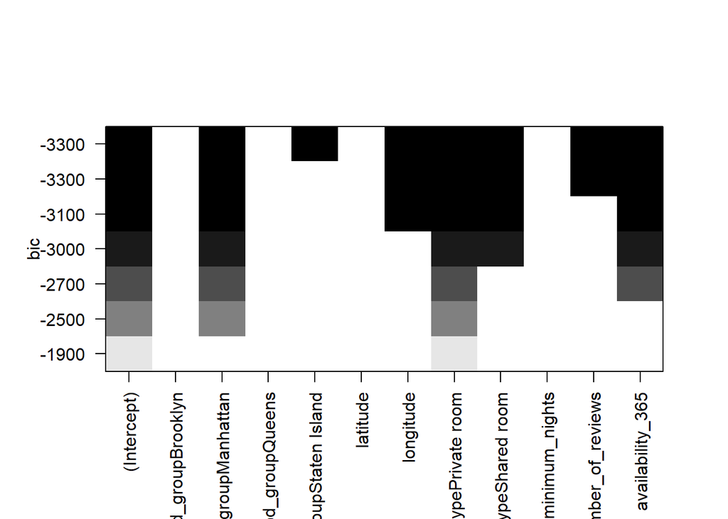

```r
plot(regfit.full,scale="bic")
```

```r
coef(regfit.full,6) # Gives the values of coefficients when number of variables are 6.
```

```
##                  (Intercept) neighbourhood_groupManhattan
##                -2.710319e+04                 4.731201e+01
##                    longitude        room_typePrivate room
##                -3.687975e+02                -1.067861e+02
##         room_typeShared room            number_of_reviews
##                -1.405289e+02                -3.197514e-01
##             availability_365
##                 1.951389e-01
```

#### Forward and Backward Stepwise Selection

```r
# Forward Method: Start with no variables and keep adding variables one at a time
regfit.fwd=regsubsets(price~., data =train, nvmax=7, method= 'forward')
fwd.sum<-summary(regfit.fwd)
fwd.sum
```

```
## Subset selection object
## Call: regsubsets.formula(price ~ ., data = train, nvmax = 7, method = "forward")
## 11 Variables  (and intercept)
##                                  Forced in Forced out
## neighbourhood_groupBrooklyn          FALSE      FALSE
## neighbourhood_groupManhattan         FALSE      FALSE
## neighbourhood_groupQueens            FALSE      FALSE
## neighbourhood_groupStaten Island     FALSE      FALSE
## latitude                             FALSE      FALSE
## longitude                            FALSE      FALSE
## room_typePrivate room                FALSE      FALSE
## room_typeShared room                 FALSE      FALSE
## minimum_nights                       FALSE      FALSE
## number_of_reviews                    FALSE      FALSE
## availability_365                     FALSE      FALSE
## 1 subsets of each size up to 7
## Selection Algorithm: forward
##          neighbourhood_groupBrooklyn neighbourhood_groupManhattan
## 1  ( 1 ) " "                         " "
## 2  ( 1 ) " "                         "*"
## 3  ( 1 ) " "                         "*"
## 4  ( 1 ) " "                         "*"
## 5  ( 1 ) " "                         "*"
## 6  ( 1 ) " "                         "*"
## 7  ( 1 ) " "                         "*"
##          neighbourhood_groupQueens neighbourhood_groupStaten Island latitude
## 1  ( 1 ) " "                       " "                              " "
## 2  ( 1 ) " "                       " "                              " "
## 3  ( 1 ) " "                       " "                              " "
## 4  ( 1 ) " "                       " "                              " "
## 5  ( 1 ) " "                       " "                              " "
## 6  ( 1 ) " "                       " "                              " "
## 7  ( 1 ) " "                       "*"                              " "
##          longitude room_typePrivate room room_typeShared room minimum_nights
## 1  ( 1 ) " "       "*"                   " "                  " "
## 2  ( 1 ) " "       "*"                   " "                  " "
## 3  ( 1 ) " "       "*"                   " "                  " "
## 4  ( 1 ) " "       "*"                   "*"                  " "
## 5  ( 1 ) "*"       "*"                   "*"                  " "
## 6  ( 1 ) "*"       "*"                   "*"                  " "
## 7  ( 1 ) "*"       "*"                   "*"                  " "
##          number_of_reviews availability_365
## 1  ( 1 ) " "               " "
## 2  ( 1 ) " "               " "
## 3  ( 1 ) " "               "*"
## 4  ( 1 ) " "               "*"
## 5  ( 1 ) " "               "*"
## 6  ( 1 ) "*"               "*"
## 7  ( 1 ) "*"               "*"
```

```r
library(data.table)
data.table(vars = 1:7, bic = fwd.sum$bic, adjr2 = fwd.sum$adjr2, cp = fwd.sum$cp)
```

```
##    vars       bic      adjr2         cp
## 1:    1 -1910.892 0.05485080 1512.54204
## 2:    2 -2495.315 0.07110886  898.82526
## 3:    3 -2744.277 0.07809549  635.66152
## 4:    4 -3009.454 0.08546293  358.11645
## 5:    5 -3148.882 0.08943214  209.05434
## 6:    6 -3261.223 0.09266633   87.78711
## 7:    7 -3281.848 0.09346300   58.66908
```

Forward selection suggests having all 7 variables will give lowest cp and highest adjust R^2.

#### Backward Method: Start with all variables and keep removing variables one at a time

```r
regfit.bwd=regsubsets(price~., data =train, nvmax=7,method="backward")
bwd.sum<-summary(regfit.bwd)
bwd.sum
```

```
## Subset selection object
## Call: regsubsets.formula(price ~ ., data = train, nvmax = 7, method = "backward")
## 11 Variables  (and intercept)
##                                  Forced in Forced out
## neighbourhood_groupBrooklyn          FALSE      FALSE
## neighbourhood_groupManhattan         FALSE      FALSE
## neighbourhood_groupQueens            FALSE      FALSE
## neighbourhood_groupStaten Island     FALSE      FALSE
## latitude                             FALSE      FALSE
## longitude                            FALSE      FALSE
## room_typePrivate room                FALSE      FALSE
## room_typeShared room                 FALSE      FALSE
## minimum_nights                       FALSE      FALSE
## number_of_reviews                    FALSE      FALSE
## availability_365                     FALSE      FALSE
## 1 subsets of each size up to 7
## Selection Algorithm: backward
##          neighbourhood_groupBrooklyn neighbourhood_groupManhattan
## 1  ( 1 ) " "                         " "
## 2  ( 1 ) " "                         " "
## 3  ( 1 ) " "                         " "
## 4  ( 1 ) " "                         " "
## 5  ( 1 ) "*"                         " "
## 6  ( 1 ) "*"                         " "
## 7  ( 1 ) "*"                         " "
##          neighbourhood_groupQueens neighbourhood_groupStaten Island latitude
## 1  ( 1 ) " "                       " "                              " "
## 2  ( 1 ) " "                       " "                              " "
## 3  ( 1 ) " "                       " "                              " "
## 4  ( 1 ) " "                       " "                              " "
## 5  ( 1 ) " "                       " "                              " "
## 6  ( 1 ) " "                       " "                              " "
## 7  ( 1 ) " "                       "*"                              " "
##          longitude room_typePrivate room room_typeShared room minimum_nights
## 1  ( 1 ) " "       "*"                   " "                  " "
## 2  ( 1 ) "*"       "*"                   " "                  " "
## 3  ( 1 ) "*"       "*"                   " "                  " "
## 4  ( 1 ) "*"       "*"                   "*"                  " "
## 5  ( 1 ) "*"       "*"                   "*"                  " "
## 6  ( 1 ) "*"       "*"                   "*"                  " "
## 7  ( 1 ) "*"       "*"                   "*"                  " "
##          number_of_reviews availability_365
## 1  ( 1 ) " "               " "
## 2  ( 1 ) " "               " "
## 3  ( 1 ) " "               "*"
## 4  ( 1 ) " "               "*"
## 5  ( 1 ) " "               "*"
## 6  ( 1 ) "*"               "*"
## 7  ( 1 ) "*"               "*"
```

```r
data.table(vars = 1:7, bic = bwd.sum$bic, adjr2 = bwd.sum$adjr2, cp = bwd.sum$cp)
```

```
##    vars       bic      adjr2         cp
## 1:    1 -1910.892 0.05485080 1512.54204
## 2:    2 -2319.345 0.06632074 1079.85084
## 3:    3 -2623.897 0.07484722  758.46595
## 4:    4 -2875.920 0.08188785  493.27266
## 5:    5 -3074.281 0.08744524  284.16701
## 6:    6 -3186.990 0.09069627  162.26097
## 7:    7 -3281.758 0.09346062   58.75929
```

Backward selection also suggests having all 7 variables will give the lowest cp and the highest adjust R^2.

#### Logistic Regression

“price” in our dataset is a continuous variable, so we now categorize it to be a categorical variable taking value 0 and 1: 0 = low price and 1 = high price.

```r
price01 <- rep(0, length(airbnb2$price))
price01[airbnb2$price > median(airbnb2$price)] <- 1 # Create a variable to represent high price.
airbnb2.ca <- data.frame(airbnb2, price01)
```

```r
#View(airbnb2.ca)
```

split data into training and testing data

```r
#split data
set.seed(211)
index.ca=sample(1:nrow(airbnb2),.7*nrow(airbnb2),replace=FALSE)
train.ca = airbnb2.ca[index.ca,]
test.ca = airbnb2.ca[-index.ca,]
```

Logisitc Regression approach: glm() method

```r
# use glm() (general linear model) with family = "binomial" to fit a logistic regression.
logit.reg <- glm(price01 ~ . -price, data = train.ca, family = "binomial")
options(scipen=999) # Disable scientific notation
summary(logit.reg)
```

```
##
## Call:
## glm(formula = price01 ~ . - price, family = "binomial", data = train.ca)
##
## Deviance Residuals:
##     Min       1Q   Median       3Q      Max
## -2.7186  -0.5644  -0.1134   0.5917   3.9468
##
## Coefficients:
##                                      Estimate   Std. Error z value
## (Intercept)                      -903.1099696   48.2613160 -18.713
## neighbourhood_groupBrooklyn        -0.2714713    0.1334469  -2.034
## neighbourhood_groupManhattan        1.0520073    0.1234778   8.520
## neighbourhood_groupQueens           0.3453203    0.1300660   2.655
## neighbourhood_groupStaten Island   -3.9646919    0.2538422 -15.619
## latitude                           -3.3419877    0.4444341  -7.520
## longitude                         -14.0653550    0.5465822 -25.733
## room_typePrivate room              -3.1503796    0.0324529 -97.075
## room_typeShared room               -4.0230103    0.1224069 -32.866
## minimum_nights                     -0.0074501    0.0008497  -8.768
## number_of_reviews                  -0.0025105    0.0003432  -7.314
## availability_365                    0.0028372    0.0001239  22.893
##                                              Pr(>|z|)
## (Intercept)                      < 0.0000000000000002 ***
## neighbourhood_groupBrooklyn                   0.04192 *
## neighbourhood_groupManhattan     < 0.0000000000000002 ***
## neighbourhood_groupQueens                     0.00793 **
## neighbourhood_groupStaten Island < 0.0000000000000002 ***
## latitude                           0.0000000000000549 ***
## longitude                        < 0.0000000000000002 ***
## room_typePrivate room            < 0.0000000000000002 ***
## room_typeShared room             < 0.0000000000000002 ***
## minimum_nights                   < 0.0000000000000002 ***
## number_of_reviews                  0.0000000000002585 ***
## availability_365                 < 0.0000000000000002 ***
## ---
## Signif. codes:  0 '***' 0.001 '**' 0.01 '*' 0.05 '.' 0.1 ' ' 1
##
## (Dispersion parameter for binomial family taken to be 1)
##
##     Null deviance: 47447  on 34225  degrees of freedom
## Residual deviance: 28171  on 34214  degrees of freedom
## AIC: 28195
##
## Number of Fisher Scoring iterations: 5
```

```r
# use predict() with type = "response" to compute predicted probabilities.
logit.reg.pred <- predict(logit.reg, test.ca, type = "response") # exclude continuous price
```

When the other variables are fixed, neighbourhood_group = Manhattan has higher price than other groups.

#### Model Evaluation

```r
library(caret)
# Cutoff = 0.5
confusionMatrix(as.factor(ifelse(logit.reg.pred > 0.5, 1, 0)), as.factor(test.ca$price01))
```

```
## Confusion Matrix and Statistics
##
##           Reference
## Prediction    0    1
##          0 5931 1204
##          1 1416 6118
##
##                Accuracy : 0.8214
##                  95% CI : (0.8151, 0.8276)
##     No Information Rate : 0.5009
##     P-Value [Acc > NIR] : < 0.00000000000000022
##
##                   Kappa : 0.6428
##
##  Mcnemar's Test P-Value : 0.00003752
##
##             Sensitivity : 0.8073
##             Specificity : 0.8356
##          Pos Pred Value : 0.8313
##          Neg Pred Value : 0.8121
##              Prevalence : 0.5009
##          Detection Rate : 0.4043
##    Detection Prevalence : 0.4864
##       Balanced Accuracy : 0.8214
##
##        'Positive' Class : 0
##
```

```r
# Cutoff = 0.7
#confusionMatrix(as.factor(ifelse(logit.reg.pred > 0.7, 1, 0)), as.factor(test.ca))

# Cutoff = 0.3
#confusionMatrix(as.factor(ifelse(logit.reg.pred > 0.3, 1, 0)), as.factor(test.ca))
```

```r
# Let's try different cut off value.
# Cutoff = 0.7
confusionMatrix(as.factor(ifelse(logit.reg.pred > 0.7, 1, 0)), as.factor(test.ca$price01))
```

```
## Confusion Matrix and Statistics
##
##           Reference
## Prediction    0    1
##          0 6521 2253
##          1  826 5069
##
##                Accuracy : 0.7901
##                  95% CI : (0.7834, 0.7967)
##     No Information Rate : 0.5009
##     P-Value [Acc > NIR] : < 0.00000000000000022
##
##                   Kappa : 0.5801
##
##  Mcnemar's Test P-Value : < 0.00000000000000022
##
##             Sensitivity : 0.8876
##             Specificity : 0.6923
##          Pos Pred Value : 0.7432
##          Neg Pred Value : 0.8599
##              Prevalence : 0.5009
##          Detection Rate : 0.4445
##    Detection Prevalence : 0.5981
##       Balanced Accuracy : 0.7899
##
##        'Positive' Class : 0
##
```

```r
# Cutoff = 0.3
confusionMatrix(as.factor(ifelse(logit.reg.pred > 0.3, 1, 0)), as.factor(test.ca$price01))
```

```
## Confusion Matrix and Statistics
##
##           Reference
## Prediction    0    1
##          0 5173  681
##          1 2174 6641
##
##                Accuracy : 0.8054
##                  95% CI : (0.7989, 0.8118)
##     No Information Rate : 0.5009
##     P-Value [Acc > NIR] : < 0.00000000000000022
##
##                   Kappa : 0.6109
##
##  Mcnemar's Test P-Value : < 0.00000000000000022
##
##             Sensitivity : 0.7041
##             Specificity : 0.9070
##          Pos Pred Value : 0.8837
##          Neg Pred Value : 0.7534
##              Prevalence : 0.5009
##          Detection Rate : 0.3526
##    Detection Prevalence : 0.3991
##       Balanced Accuracy : 0.8055
##
##        'Positive' Class : 0
##
```

It seems like the accuracy decreases while cut off increase or decrease from 0.5. What is the right cutoff? Let’s do the above exercise for all cutoffs.

```r
# create empty accuracy table
accT = c()
# compute accuracy per cutoff
for (cut in seq(0,1,0.1)){
  cm <- confusionMatrix(as.factor(1 * (logit.reg.pred > cut)), as.factor(test.ca$price01))
  accT = c(accT, cm$overall[1])
}
```

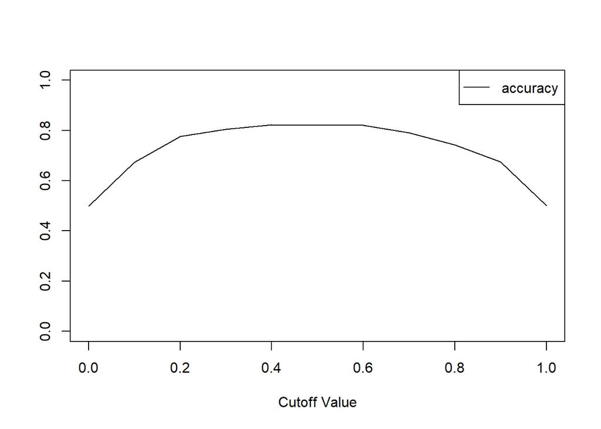

```r
# You can use the above for loop for finding the optimal threshold.

# plot accuracy
plot(accT ~ seq(0,1,0.1), xlab = "Cutoff Value", ylab = "", type = "l", ylim = c(0, 1))
#lines(1-accT ~ seq(0,1,0.1), type = "l", lty = 2)
legend("topright",  c("accuracy"), lty = c(1, 2), merge = TRUE)
```

```r
print(accT)
```

```
##  Accuracy  Accuracy  Accuracy  Accuracy  Accuracy  Accuracy  Accuracy  Accuracy
## 0.4991479 0.6740064 0.7770127 0.8053719 0.8222783 0.8213921 0.8209149 0.7901016
##  Accuracy  Accuracy  Accuracy
## 0.7427909 0.6753017 0.5008521
```

```r
which.max(accT)
```

```
## Accuracy
##        5
```

The fifth cutoff = 0.4 gives the highest accuracy = 0.8223.

#### Automating the above steps for all possible cutoffs: ROC Curve

```r
library(pROC)
r <- roc(test.ca$price01, logit.reg.pred)
```

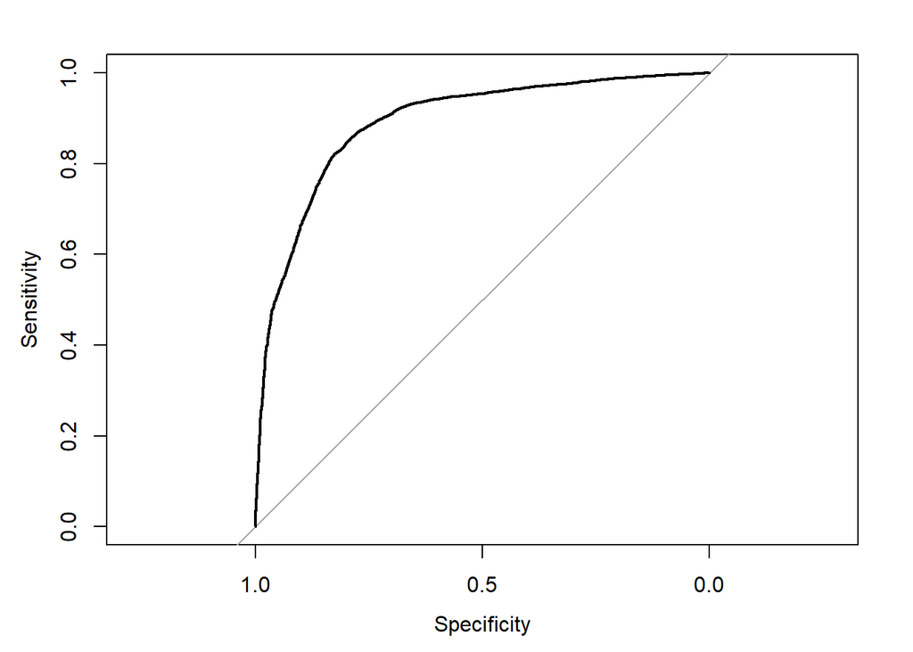

```r
plot.roc(r)
```

```r
auc(r)
```

```
## Area under the curve: 0.8901
```

We found that the area under the curve: 0.8901.

#### Tree-based prediction approaches using rpart package

First, we fit a decision tree model.

```r
# The complexity parameter (cp) is used to control the size of the decision tree. cp = 0 means deepest tree.
# Try using cp = 0.01 etc.
library(rpart)
deeper.ct <- rpart(price01 ~ .-price, data = train.ca, method = "class", cp = 0.01, minsplit = 1)

# Count number of leaves
length(deeper.ct$frame$var[deeper.ct$frame$var == "<leaf>"])
```

```
## [1] 2
```

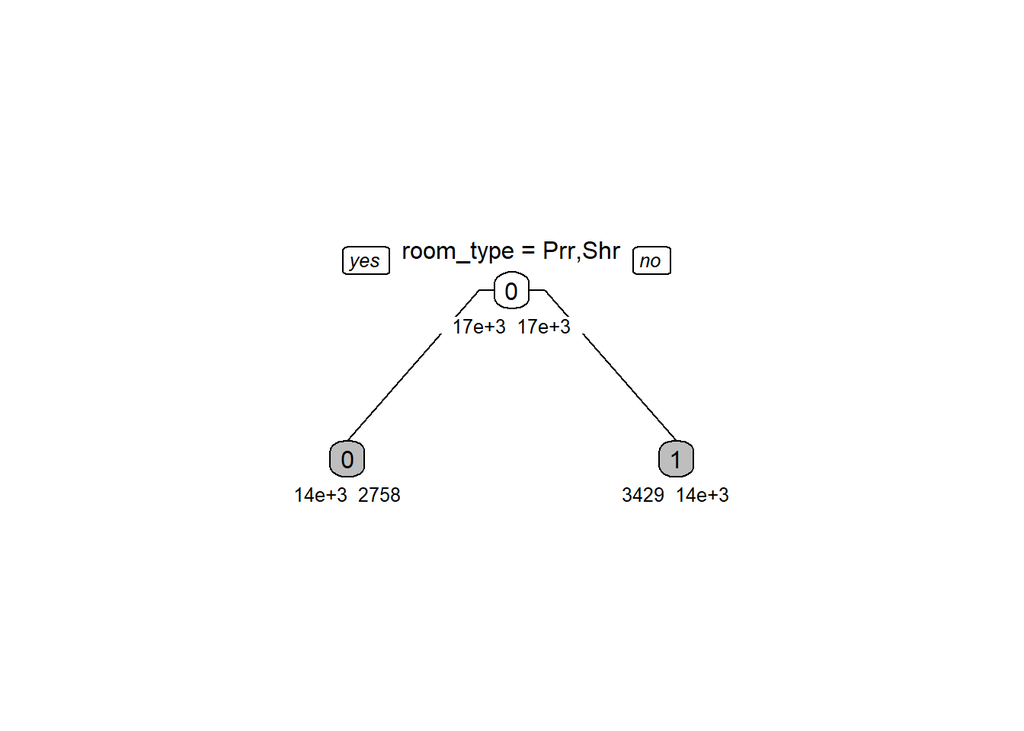

```r
# Plot tree
library(rpart.plot)
prp(deeper.ct, type = 1, extra = 1, under = TRUE, split.font = 1, varlen = -10, #extra = 1 display the number of observations that fall in the node;varlen = Default -8, meaning truncate to eight characters.
    box.col=ifelse(deeper.ct$frame$var == "<leaf>", 'gray', 'white'))
```

##### Pruning: Finding the right depth of the tree.

```r
set.seed(211)
# minsplit: The minimum number of observations in a node for a split to be attempted.
# xval: The number K of folds in a K-fold cross-validation.
cv.ct <- rpart(price01 ~ .-price, data = train.ca, method = "class", cp = 0.00001, minsplit = 1, xval = 5)

# Print out the complexity parameter (cp) table of cross-validation errors. The R-squared for a regression tree is 1 minus rel error.
# xerror (or relative cross-validation error where "x" stands for "cross") is a scaled version of overall average of the 5 out-of-sample errors across the 5 folds.
cp_table <- printcp(cv.ct)
```

```
##
## Classification tree:
## rpart(formula = price01 ~ . - price, data = train.ca, method = "class",
##     cp = 0.00001, minsplit = 1, xval = 5)
##
## Variables actually used in tree construction:
## [1] availability_365    latitude            longitude
## [4] minimum_nights      neighbourhood_group number_of_reviews
## [7] room_type
##
## Root node error: 17101/34226 = 0.49965
##
## n= 34226
##
##             CP nsplit  rel error  xerror      xstd
```

[output cut: 79 more lines]

```r
#cp_table
```

Plotting

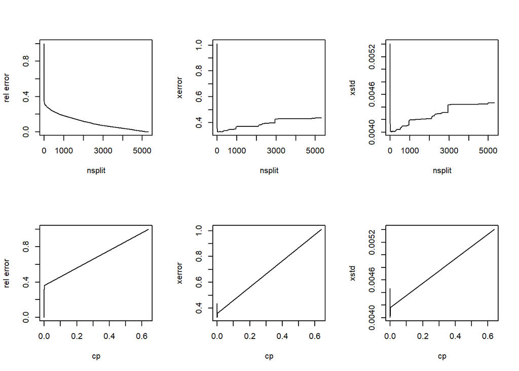

```r
par(mfrow=c(2,3))

# Plot nsplit vs errors
plot(cp_table[,2],cp_table[,3], xlab = "nsplit", ylab = "rel error", type = "l") # Plotting nsplit v/s rel error
plot(cp_table[,2],cp_table[,4], xlab = "nsplit", ylab = "xerror", type = "l") # Plotting nsplit v/s xerror
plot(cp_table[,2],cp_table[,5], xlab = "nsplit", ylab = "xstd", type = "l") # Plotting nsplit v/s xstd

# Plot cp vs errors
plot(cp_table[,1],cp_table[,3], xlab = "cp", ylab = "rel error", type = "l") # Plotting cp v/s rel error
plot(cp_table[,1],cp_table[,4], xlab = "cp", ylab = "xerror", type = "l") # Plotting cp v/s xerror
plot(cp_table[,1],cp_table[,5], xlab = "cp", ylab = "xstd", type = "l") # Plotting cp v/s xstd
```

[figure not shown]

```r
pruned.ct <- prune(cv.ct, cp = 0.000272889)
prp(pruned.ct, type = 1, extra = 1, under = TRUE, split.font = 1, varlen = -10,
    box.col=ifelse(pruned.ct$frame$var == "<leaf>", 'gray', 'white'))
```

##### Variable Importance by random forest

```r
library(randomForest)
```

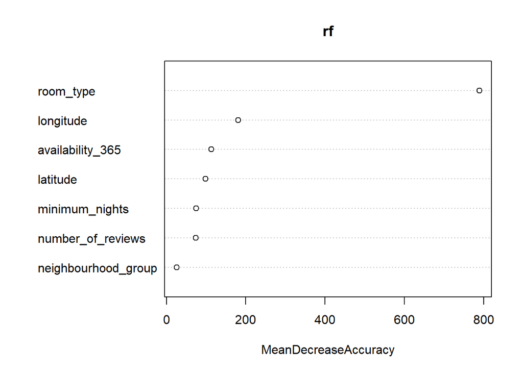

```r
library(caret)
## random forest
rf <- randomForest(as.factor(price01) ~ .-price, data = train.ca, ntree = 500,
                   mtry = 4, nodesize = 5, importance = TRUE)

## variable importance plot
varImpPlot(rf, type = 1) # type: =1 means decreasing in accuracy, =2 means decreasing in node impurity
```

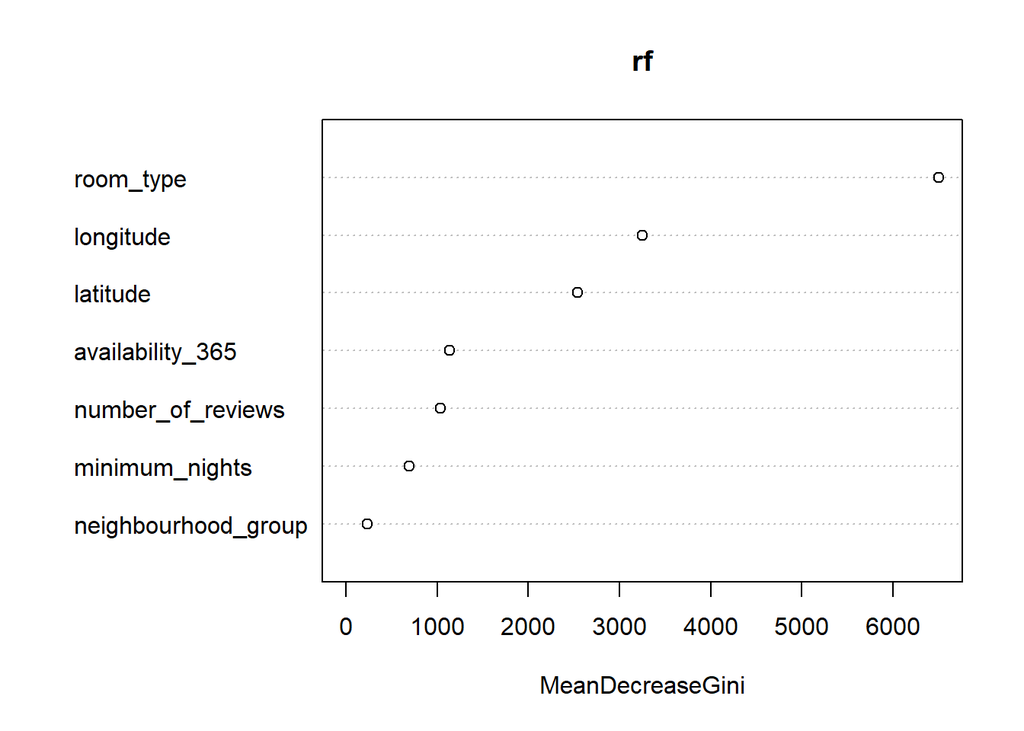

```r
varImpPlot(rf, type = 2)
```

```r
## confusion matrix

rf.pred <- predict(rf, test.ca)
confusionMatrix(as.factor(rf.pred), as.factor(test.ca$price01))
```

```
## Confusion Matrix and Statistics
##
##           Reference
## Prediction    0    1
##          0 6144 1148
##          1 1203 6174
##
##                Accuracy : 0.8397
##                  95% CI : (0.8337, 0.8456)
##     No Information Rate : 0.5009
##     P-Value [Acc > NIR] : <0.0000000000000002
##
##                   Kappa : 0.6795
##
##  Mcnemar's Test P-Value : 0.2654
##
##             Sensitivity : 0.8363
##             Specificity : 0.8432
##          Pos Pred Value : 0.8426
##          Neg Pred Value : 0.8369
##              Prevalence : 0.5009
##          Detection Rate : 0.4188
##    Detection Prevalence : 0.4971
##       Balanced Accuracy : 0.8397
##
##        'Positive' Class : 0
##
```

We found that in both two types of importance plots, room_type and longitude are the top two important variables in our model.

The accuracy of random forest model is higher than logistic regression model.

We could also use train() with method=“rf” to fit the model.

```r
library(caret)

train.ca$price01 = as.factor(train.ca$price01)
rf.tf<-train(price01 ~ .-price, data = train.ca, method = 'rf')

pred.rf <- predict(rf.tf, test.ca,type = "raw" )

confusionMatrix(pred.rf, as.factor(test.ca$price01))
```

```
## Confusion Matrix and Statistics
##
##           Reference
## Prediction    0    1
##          0 6126 1124
##          1 1221 6198
##
##                Accuracy : 0.8401
##                  95% CI : (0.8341, 0.846)
##     No Information Rate : 0.5009
##     P-Value [Acc > NIR] : < 0.0000000000000002
##
##                   Kappa : 0.6803
##
##  Mcnemar's Test P-Value : 0.04743
##
##             Sensitivity : 0.8338
##             Specificity : 0.8465
##          Pos Pred Value : 0.8450
##          Neg Pred Value : 0.8354
##              Prevalence : 0.5009
##          Detection Rate : 0.4176
##    Detection Prevalence : 0.4942
##       Balanced Accuracy : 0.8401
##
##        'Positive' Class : 0
##
```

```r
#library(pROC) #we should use type = "prob" to plot roc curve
#library(e1071)

#r.rf <- roc(test.ca$price01, pred.rf)
#plot.roc(r.rf)
#auc(r.rf)
```

##### Boosting method

```r
#install.packages("adabag")
library(adabag)
library(rpart)
library(caret)

train.ca$price01 <- as.factor(train.ca$price01)

set.seed(211)
boost <- boosting(price01 ~ .-price, data = train.ca) # It might take time to execute
pred <- predict(boost, test.ca)
confusionMatrix(as.factor(pred$class), as.factor(test.ca$price01))
```

```
## Confusion Matrix and Statistics
##
##           Reference
## Prediction    0    1
##          0 6098 1171
##          1 1249 6151
##
##                Accuracy : 0.835
##                  95% CI : (0.8289, 0.841)
##     No Information Rate : 0.5009
##     P-Value [Acc > NIR] : <0.0000000000000002
##
##                   Kappa : 0.6701
##
##  Mcnemar's Test P-Value : 0.1175
##
##             Sensitivity : 0.8300
##             Specificity : 0.8401
##          Pos Pred Value : 0.8389
##          Neg Pred Value : 0.8312
##              Prevalence : 0.5009
##          Detection Rate : 0.4157
##    Detection Prevalence : 0.4955
##       Balanced Accuracy : 0.8350
##
##        'Positive' Class : 0
##
```

The accuracy is a little bit lower than that of random forest model.

We could also use train() with method=‘adaboost’ to fit the model and plot roc curve.

```r
#library(fastAdaboost)
#ab_boost <- train(price01 ~ .-price, data = train.ca, method = 'adaboost')
#pred.bst <- predict(ab_boost, test.ca,type = "prob" )

#confusionMatrix(pred.bst, as.factor(test.ca$price01))
```

```r
#library(pROC) #we should use type = "prob" to plot roc curve
#library(e1071)

#r.boost <- roc(test.ca$price01, pred.bst)
#plot.roc(r.boost)
#auc(r.boost)
```

Next, we will use train() function of the caret package to run bagging and boosting.

Run bagging algorithm using method = “treebag” in the train() function.

```r
set.seed(211)
bag <- train(price01 ~ .-price, data = train.ca, method = 'treebag')

pred_bag <- predict(bag, test.ca,type = "raw" )

confusionMatrix(pred_bag, as.factor(test.ca$price01))
```

```
## Confusion Matrix and Statistics
##
##           Reference
## Prediction    0    1
##          0 6088 1162
##          1 1259 6160
##
##                Accuracy : 0.835
##                  95% CI : (0.8289, 0.8409)
##     No Information Rate : 0.5009
##     P-Value [Acc > NIR] : < 0.0000000000000002
##
##                   Kappa : 0.6699
##
##  Mcnemar's Test P-Value : 0.05105
##
##             Sensitivity : 0.8286
##             Specificity : 0.8413
##          Pos Pred Value : 0.8397
##          Neg Pred Value : 0.8303
##              Prevalence : 0.5009
##          Detection Rate : 0.4150
##    Detection Prevalence : 0.4942
##       Balanced Accuracy : 0.8350
##
##        'Positive' Class : 0
##
```

The accuracy is also a little bit lower than that of random forest model but higher than logistic regression model.

#### XGBoost (eXtreme Gradient Boosting): An implementation of gradient boosted decision trees designed for speed and performance.

```r
library(xgboost)
set.seed(211)
xgbst <- train(price01 ~ .-price, data = train.ca, method = 'xgbTree')

pred_xgbst <- predict(xgbst, test.ca,type = "raw" )

confusionMatrix(pred_xgbst, as.factor(test.ca$price01))
```

```
## Confusion Matrix and Statistics
##
##           Reference
## Prediction    0    1
##          0 6054 1087
##          1 1293 6235
##
##                Accuracy : 0.8378
##                  95% CI : (0.8317, 0.8437)
##     No Information Rate : 0.5009
##     P-Value [Acc > NIR] : < 0.00000000000000022
##
##                   Kappa : 0.6755
##
##  Mcnemar's Test P-Value : 0.00002645
##
##             Sensitivity : 0.8240
##             Specificity : 0.8515
##          Pos Pred Value : 0.8478
##          Neg Pred Value : 0.8282
##              Prevalence : 0.5009
##          Detection Rate : 0.4127
##    Detection Prevalence : 0.4868
##       Balanced Accuracy : 0.8378
##
##        'Positive' Class : 0
##
```

The accuracy is also a little bit lower than that of random forest model but higher than all the other models.

#### Train a knn model: Use train(x,y,method=‘knn’) for knn

```r
set.seed(211)
knn <- train(price01 ~ .-price, data = train.ca, method = 'knn')
pred_knn <- predict(knn, test.ca,type = "raw" )
confusionMatrix(pred_knn, as.factor(test.ca$price01))
```

```
## Confusion Matrix and Statistics
##
##           Reference
## Prediction    0    1
##          0 4763 2115
##          1 2584 5207
##
##                Accuracy : 0.6797
##                  95% CI : (0.672, 0.6872)
##     No Information Rate : 0.5009
##     P-Value [Acc > NIR] : < 0.00000000000000022
##
##                   Kappa : 0.3594
##
##  Mcnemar's Test P-Value : 0.000000000008658
##
##             Sensitivity : 0.6483
##             Specificity : 0.7111
##          Pos Pred Value : 0.6925
##          Neg Pred Value : 0.6683
##              Prevalence : 0.5009
##          Detection Rate : 0.3247
##    Detection Prevalence : 0.4689
##       Balanced Accuracy : 0.6797
##
##        'Positive' Class : 0
##
```

The accuracy of KNN model is the lowest one among all models we had above.

#### Fitting classification Trees with pruning.

```r
#install.packages("tree")
library(tree)
library(caret)
```

Fit the classification tree.

```r
tree.ca=tree(price01~.-price,airbnb2.ca) # Removing the variable "Sales", because the variable "High" is derived from it.
tree.ca
```

```
## node), split, n, deviance, yval
##       * denotes terminal node
##
##  1) root 48895 12220.0 0.4995
##    2) longitude < -73.9634 19924  4071.0 0.7138
##      4) latitude < 40.6605 1741   345.9 0.2734 *
##      5) latitude > 40.6605 18183  3355.0 0.7559 *
##    3) longitude > -73.9634 28971  6609.0 0.3521
##      6) longitude < -73.9413 14257  3525.0 0.4474
##       12) latitude < 40.7098 5441  1198.0 0.3271 *
##       13) latitude > 40.7098 8816  2200.0 0.5216 *
##      7) longitude > -73.9413 14714  2830.0 0.2599 *
```

```r
summary(tree.ca) # Residual mean deviance: Related to the mean squared error
```

```
##
## Regression tree:
## tree(formula = price01 ~ . - price, data = airbnb2.ca)
## Variables actually used in tree construction:
## [1] "longitude" "latitude"
## Number of terminal nodes:  5
## Residual mean deviance:  0.2031 = 9928 / 48890
## Distribution of residuals:
##    Min. 1st Qu.  Median    Mean 3rd Qu.    Max.
## -0.7559 -0.3271 -0.2599  0.0000  0.2441  0.7401
```

Plot the tree

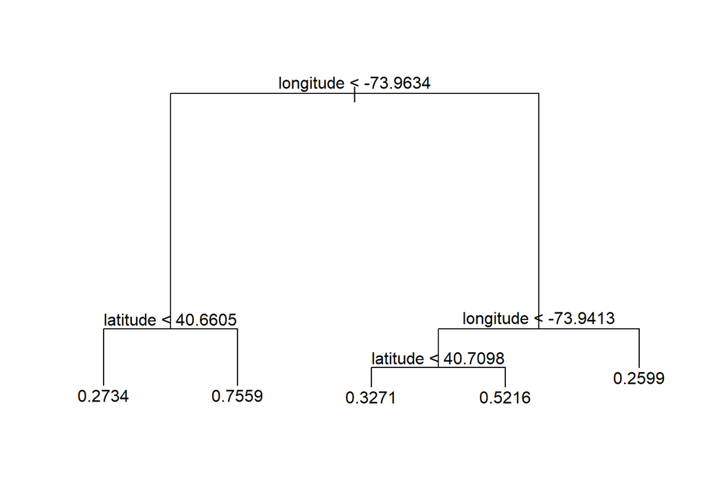

```r
plot(tree.ca)
text(tree.ca,pretty=0) # pretty=0: instructs R to include the category names for any qualitative predictors, rather than simply displaying a letter for each category (which is what pretty=1 does).
```

Partition the data into test and train, then predict.

```r
set.seed(211)

# Training Data
train=sample(1:nrow(airbnb2.ca), 200) # Randomly select 10000 number between 1 to nrow(B)

# Test Data
B.test=airbnb2.ca[-train,]
price.test=price01[-train]

# Training Decision Tree
tree.b=tree(as.factor(price01)~.-price,airbnb2.ca,subset=train)
# Prediction using Decision Tree
tree.bpred=predict(tree.b,B.test, type = "class")
# Assess accuracy
confusionMatrix(tree.bpred, as.factor(price.test))
```

```
## Confusion Matrix and Statistics
##
##           Reference
## Prediction     0     1
##          0 13734  6717
##          1 10643 17601
##
##                Accuracy : 0.6435
##                  95% CI : (0.6392, 0.6478)
##     No Information Rate : 0.5006
##     P-Value [Acc > NIR] : < 0.00000000000000022
##
##                   Kappa : 0.2871
##
##  Mcnemar's Test P-Value : < 0.00000000000000022
##
##             Sensitivity : 0.5634
##             Specificity : 0.7238
##          Pos Pred Value : 0.6716
##          Neg Pred Value : 0.6232
##              Prevalence : 0.5006
##          Detection Rate : 0.2820
##    Detection Prevalence : 0.4200
##       Balanced Accuracy : 0.6436
##
##        'Positive' Class : 0
##
```

We see that the accuracy is very low (only 64.35%). Let’s prune this tree. But what is the right size to prune?

```r
# ?cv.tree # Cross-validation for Choosing Tree Complexity: Runs a K-fold cross-validation experiment to find the deviance or number of misclassifications as a function of the cost-complexity parameter k.
set.seed (211)
cv.treeb =cv.tree(tree.b ,FUN=prune.misclass )
```

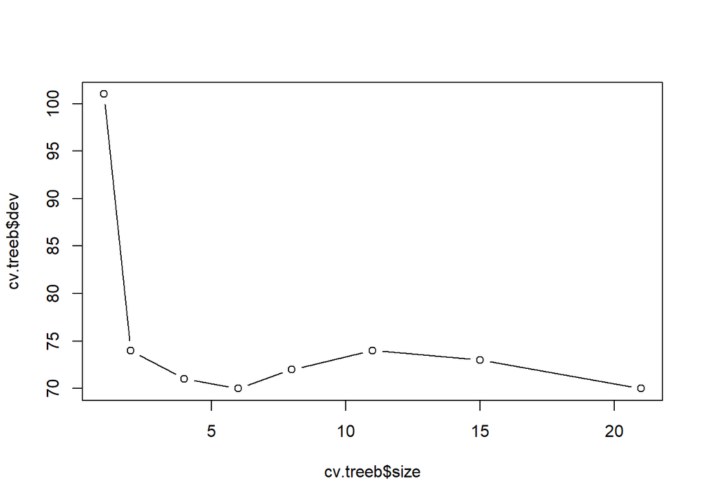

```r
plot(cv.treeb$size ,cv.treeb$dev ,type="b")
```

```r
cv.treeb$size
```

```
## [1] 21 15 11  8  6  4  2  1
```

```r
cv.treeb$dev
```

```
## [1]  70  73  74  72  70  71  74 101
```

We see that the error (dev or deviance) is minimized around size 6 (this number may change depending on the value of seed chosen, this also illustrates how unstable decision trees are).

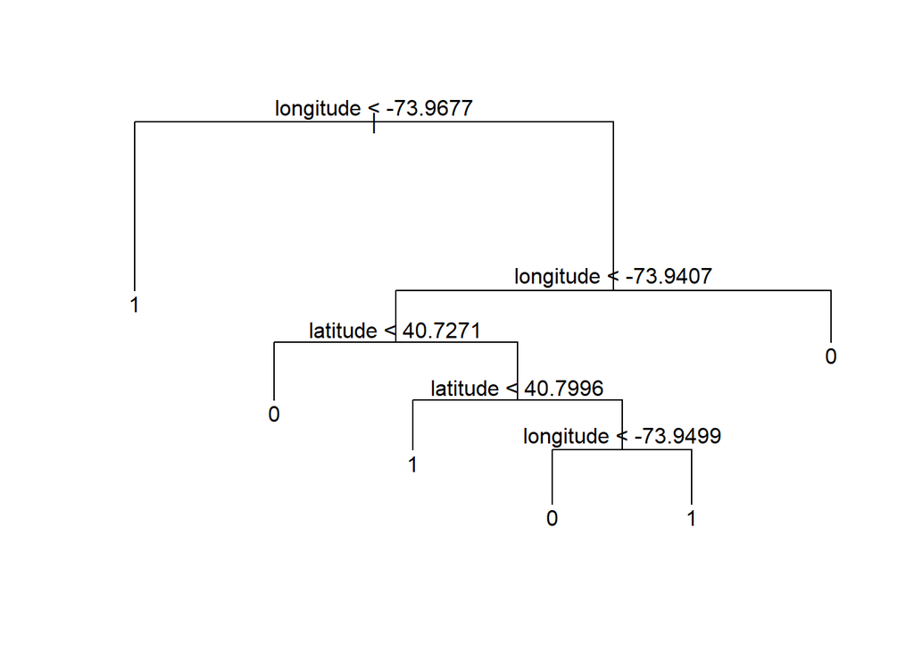

```r
prune.treeb=prune.misclass(tree.b,best=6)
# Prune down to 5 leaf nodes. Pruning level is a "hyper-parameter".

plot(prune.treeb)
text(prune.treeb,pretty=0)
```

```r
tree.pred=predict(prune.treeb,test.ca,type="class")
table(as.factor(test.ca$price01), tree.pred)
```

```
##    tree.pred
##        0    1
##   0 5131 2216
##   1 2493 4829
```

```r
confusionMatrix(tree.pred, as.factor(test.ca$price01))
```

```
## Confusion Matrix and Statistics
##
##           Reference
## Prediction    0    1
##          0 5131 2493
##          1 2216 4829
##
##                Accuracy : 0.679
##                  95% CI : (0.6714, 0.6865)
##     No Information Rate : 0.5009
##     P-Value [Acc > NIR] : < 0.00000000000000022
##
##                   Kappa : 0.3579
##
##  Mcnemar's Test P-Value : 0.0000577
##
##             Sensitivity : 0.6984
##             Specificity : 0.6595
##          Pos Pred Value : 0.6730
##          Neg Pred Value : 0.6855
##              Prevalence : 0.5009
##          Detection Rate : 0.3498
##    Detection Prevalence : 0.5197
##       Balanced Accuracy : 0.6789
##
##        'Positive' Class : 0
##
```

We see that pruning has increased accuracy from 64.35% to 67.9%!

#### Fitting Regression Trees with pruning

Using “price” as response variable instead of price01 (Predicting a numerical value using decision trees).

```r
set.seed(211)
train.reg = sample(1:nrow(airbnb2), nrow(airbnb2)*0.7) # Use half of datapoints as training data
tree.reg=tree(price~.,airbnb2,subset=train.reg)
summary(tree.reg)
```

```
##
## Regression tree:
## tree(formula = price ~ ., data = airbnb2, subset = train.reg)
## Variables actually used in tree construction:
## [1] "longitude"        "availability_365"
## Number of terminal nodes:  3
## Residual mean deviance:  57440 = 1966000000 / 34220
## Distribution of residuals:
##    Min. 1st Qu.  Median    Mean 3rd Qu.    Max.
##  -409.4   -67.0   -35.0     0.0    21.0  9885.0
```

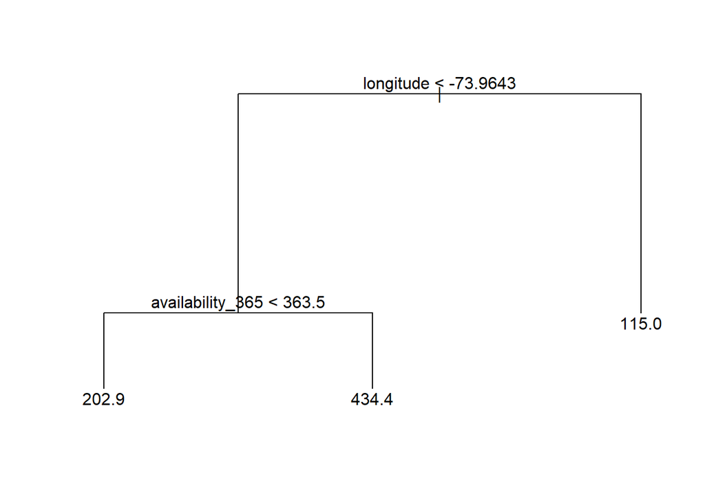

```r
plot(tree.reg)
text(tree.reg,pretty=0)
```

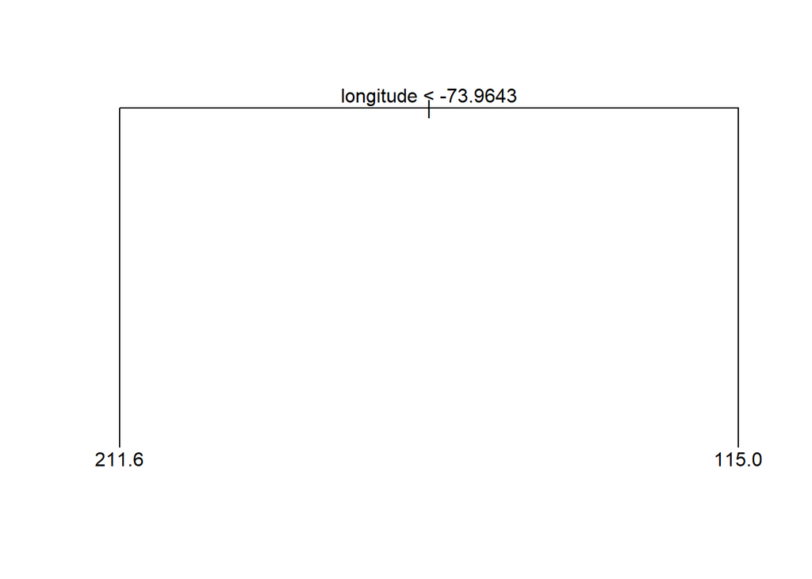

```r
prune.reg=prune.tree(tree.reg,best=2) #the largest size that can be pruned

plot(prune.reg)
text(prune.reg,pretty=0)
```

```r
yhat=predict(tree.reg,newdata=airbnb2[-train,])
```

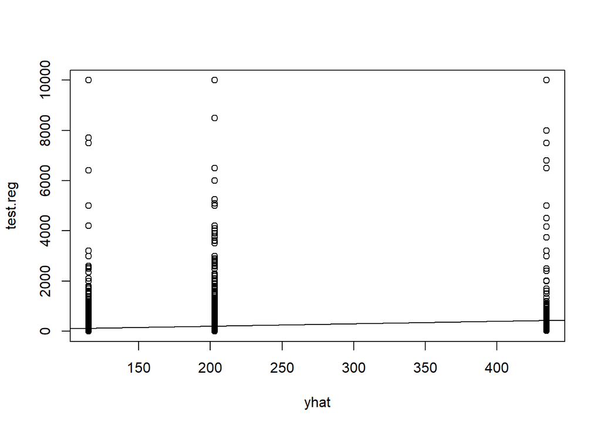

```r
test.reg=airbnb2[-train,"price"]
plot(yhat,test.reg)
abline(0,1)
```

```r
mean((yhat-test.reg)^2)
```

```
## [1] 55196.96
```

The plot looks a like *three slabs*, because for all the test points corresponding to a leaf node, the decision tree predicts the exact same value.

#### Bagging, Random Forests, and Boosting

##### Bagging and Random Forest

```r
#install.packages("randomForest")
library(randomForest)
set.seed(211)
#dim(airbnb2)
bag.reg=randomForest(price~.,data=airbnb2,subset=train.reg,mtry=7,importance=TRUE) # mtry=7 indicates that ALL 7 predictors should be considered for each split of the tree. In other words, bagging should be done
bag.reg
```

```
##
## Call:
##  randomForest(formula = price ~ ., data = airbnb2, mtry = 7, importance = TRUE,      subset = train.reg)
##                Type of random forest: regression
##                      Number of trees: 500
## No. of variables tried at each split: 7
##
##           Mean of squared residuals: 56689.67
##                     % Var explained: 6.22
```

We see than the random forest contains 500 decision trees.

```r
yhat.bagging = predict(bag.reg,newdata=airbnb2[-train,])
#plot(yhat.bagging, test.reg)
#abline(0,1) # Straight line with intercept = 0 and slope = 1.
mean((yhat.bagging-test.reg)^2)
```

```
## [1] 23854.57
```

Let’s use mtry = 4.

```r
set.seed(1)
rf.reg=randomForest(price~.,data=airbnb2,subset=train.reg,mtry=4,importance=TRUE) # mtry = 6 (not all 13) indicates we need random forest
rf.reg
```

```
##
## Call:
##  randomForest(formula = price ~ ., data = airbnb2, mtry = 4, importance = TRUE,      subset = train.reg)
##                Type of random forest: regression
##                      Number of trees: 500
## No. of variables tried at each split: 4
##
##           Mean of squared residuals: 52997.71
##                     % Var explained: 12.33
```

```r
yhat.rfreg = predict(rf.reg,newdata=airbnb2[-train,])
mean((yhat.rfreg-test.reg)^2)
```

```
## [1] 23077.42
```

Remember: Unlike decision tree, the ensembles are not interpretable. However, the randomForest package provides some interpretability methods.

```r
importance(rf.reg) # In Result: IncMSE is based upon the mean decrease of accuracy in predictions on the out of bag samples when a given variable is excluded from the model. IncNodePurity is a measure of the total increase in purity that results from splits over that variable, averaged over all trees.
```

```
##                       %IncMSE IncNodePurity
## neighbourhood_group  4.763077      41198195
## latitude            16.588038     479682871
## longitude            6.288397     573650691
## room_type           23.666365     120456582
## minimum_nights      21.592731     208906743
## number_of_reviews   10.199292     115181361
## availability_365    29.758975     240948338
```

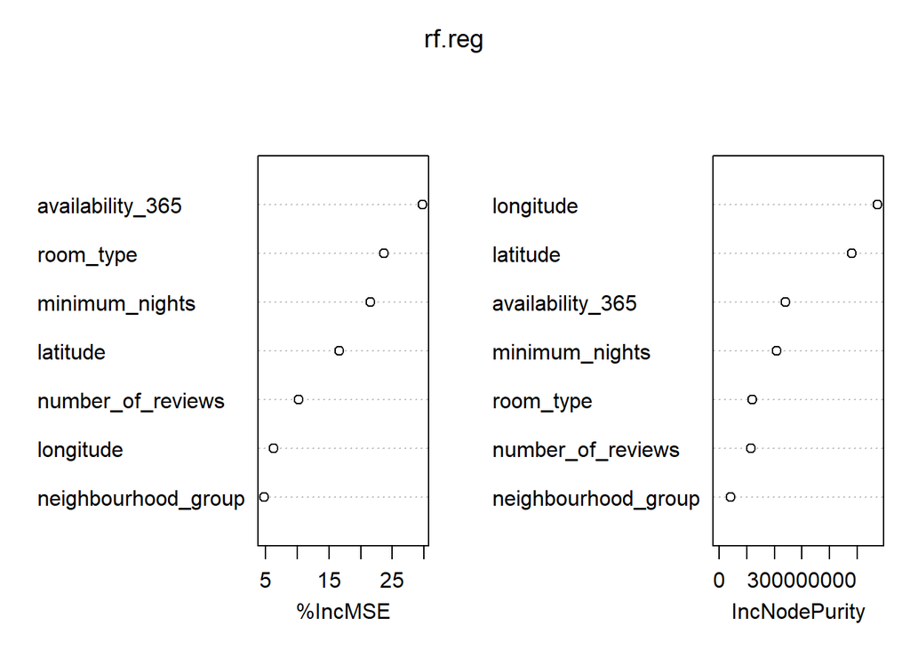

```r
varImpPlot(rf.reg)
```

*Mean Decrease Accuracy (%IncMSE)* - This shows how much our model accuracy decreases if we leave out that variable. *Mean Decrease Gini (IncNodePurity)* - This is a measure of variable importance based on the Gini impurity index used for the calculating the splits in trees.

The higher the value of mean decrease accuracy or mean decrease gini score, the higher the importance of the variable to our model.

Note: 1. We see that availability_365 has highest value of %IncMSE and longitude has the highest value of IncNodePurity. This is expected because the running of Airbnb in New York are based on the annual availability of rooms. Also, location is very important according to our exploratory analysis. 2. We also see that neighbourhood_group has lowest %IncMSE and IncNodePurity. This means that the group impact does not contribute a lot to the price of the Airbnbs in New York.

#### Let’s now apply Boosting

*Boosting*: Generalized Boosted Regression Modeling (GBM)

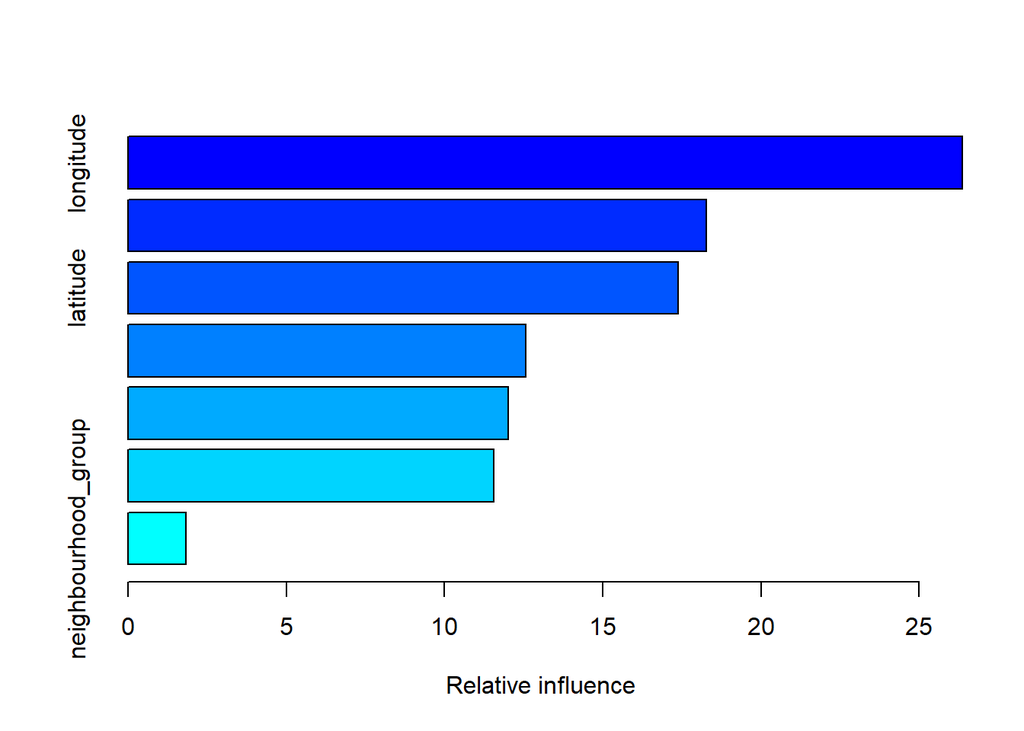

```
##                                     var   rel.inf
## longitude                     longitude 26.359391
## availability_365       availability_365 18.273030
## latitude                       latitude 17.393076
## minimum_nights           minimum_nights 12.561363
## room_type                     room_type 12.020672
## number_of_reviews     number_of_reviews 11.556784
## neighbourhood_group neighbourhood_group  1.835683
```

```r
#install.packages("gbm")
library(gbm)
set.seed(211)

airbnb2$neighbourhood_group <- as.factor(airbnb2$neighbourhood_group)
airbnb2$room_type <- as.factor(airbnb2$room_type)
boost.reg=gbm(price~.,data=airbnb2[train,],distribution="gaussian",n.trees=5000,interaction.depth=5)
summary(boost.reg) # We see that lstat and rm are by far the most important variables.
```

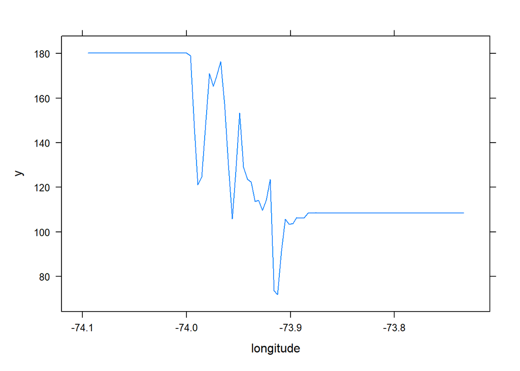

```r
plot(boost.reg,i="longitude")
```

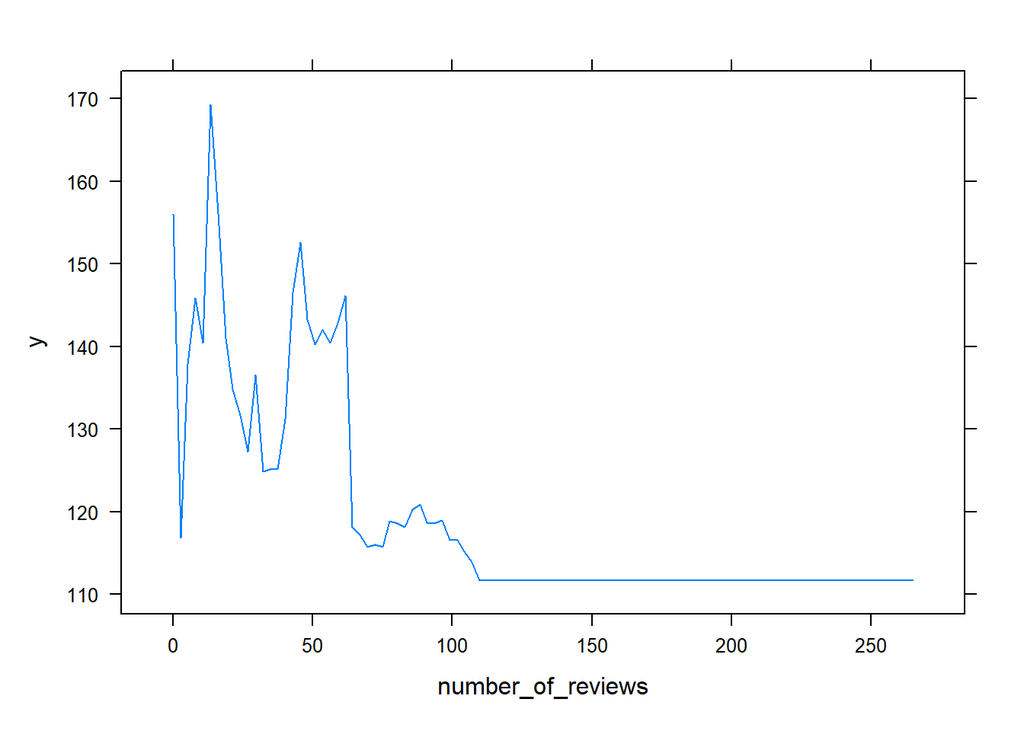

```r
plot(boost.reg,i="number_of_reviews")
```

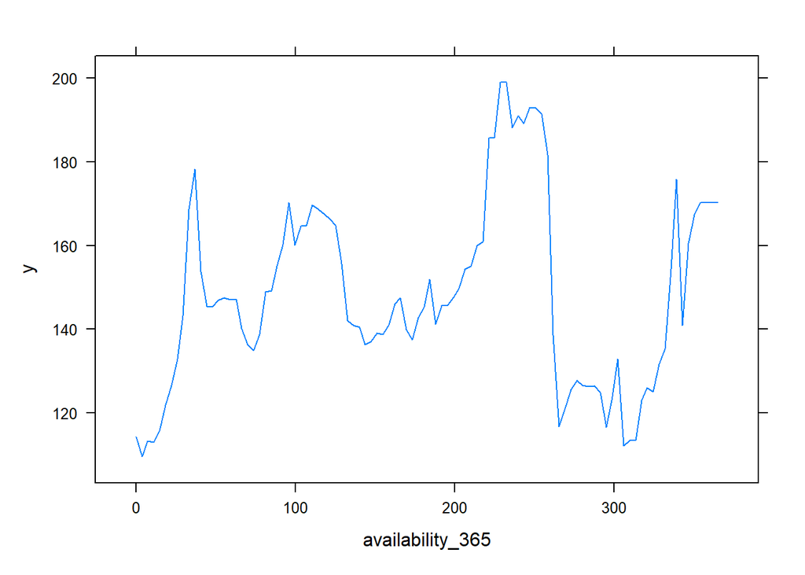

```r
plot(boost.reg,i="availability_365")
```

```r
# interaction.depth: Integer specifying the maximum depth of each tree (i.e., the highest level of variable interactions allowed).
# shrinkage (Learning Rate): Learning rate or step-size of each iteration. A bigger step-size makes execution faster, but it may not find optimal parameter.
# distribution="gaussian" suggests that we are trying to minimize the "squared error".
boost.regin=gbm(price~.,data=airbnb2[train,],distribution="gaussian",n.trees=5000,interaction.depth=4,shrinkage=0.2)
yhat.boostin=predict(boost.regin,newdata=airbnb2[-train,],n.trees=5000)
mean((yhat.boostin-test.reg)^2)
```

```
## [1] 54545.89
```

### Neural Nets

```r
#install.packages("neuralnet")
library(neuralnet)
```

Let’s try Neural Network methods. Since neural net only deals with quantitative variables, we should convert all the qualitative variables (factors) to binary (“dummy”) variables, with the model.matrix function – it is one of the very rare situations in which R does not perform the transformation for you.

```r
str(airbnb2.ca)
```

```
## 'data.frame':    48895 obs. of  9 variables:
##  $ price              : int  149 225 150 89 80 200 60 79 79 150 ...
##  $ neighbourhood_group: chr  "Brooklyn" "Manhattan" "Manhattan" "Brooklyn" ...
##  $ latitude           : num  40.6 40.8 40.8 40.7 40.8 ...
##  $ longitude          : num  -74 -74 -73.9 -74 -73.9 ...
##  $ room_type          : chr  "Private room" "Entire home/apt" "Private room" "Entire home/apt" ...
##  $ minimum_nights     : int  1 1 3 1 10 3 45 2 2 1 ...
##  $ number_of_reviews  : int  9 45 0 270 9 74 49 430 118 160 ...
##  $ availability_365   : int  365 355 365 194 0 129 0 220 0 188 ...
##  $ price01            : num  1 1 1 0 0 1 0 0 0 1 ...
```

```r
airbnb2.ca$high <- airbnb2.ca$price01 == 1 # Create dummy variable for 1=high price
airbnb2.ca$low  <- airbnb2.ca$price01 == 0 # Create dummy variable for 0=low price
#View(airbnb2.ca)

airbnb2.ca$neighbourhood_group<-factor(airbnb2.ca$neighbourhood_group, levels = c("Staten Island","Brooklyn","Manhattan", "Bronx", "Queens"), labels =c(1,2,3, 4, 5))
airbnb2.ca$room_type<-factor(airbnb2.ca$room_type, levels = c("Private room","Entire home/apt","Shared room"), labels =c(1,2,3))

str(airbnb2.ca)
```

```
## 'data.frame':    48895 obs. of  11 variables:
##  $ price              : int  149 225 150 89 80 200 60 79 79 150 ...
##  $ neighbourhood_group: Factor w/ 5 levels "1","2","3","4",..: 2 3 3 2 3 3 2 3 3 3 ...
##  $ latitude           : num  40.6 40.8 40.8 40.7 40.8 ...
##  $ longitude          : num  -74 -74 -73.9 -74 -73.9 ...
##  $ room_type          : Factor w/ 3 levels "1","2","3": 1 2 1 2 2 2 1 1 1 2 ...
##  $ minimum_nights     : int  1 1 3 1 10 3 45 2 2 1 ...
##  $ number_of_reviews  : int  9 45 0 270 9 74 49 430 118 160 ...
##  $ availability_365   : int  365 355 365 194 0 129 0 220 0 188 ...
##  $ price01            : num  1 1 1 0 0 1 0 0 0 1 ...
##  $ high               : logi  TRUE TRUE TRUE FALSE FALSE TRUE ...
##  $ low                : logi  FALSE FALSE FALSE TRUE TRUE FALSE ...
```

```r
#m <- model.matrix(
 # ~ high+low+neighbourhood_group+latitude+longitude+room_type+minimum_nights+number_of_reviews+availability_365,
  #data = airbnb2.ca)


#set.seed(211)
#nnet <-
  #neuralnet(
    #high + low ~ neighbourhood_group+latitude+longitude+room_type+minimum_nights+number_of_reviews+availability_365,
    #data = airbnb2.ca,
    #linear.output = FALSE, # linear.output = FALSE indicates that we are predicting categorical output
    #hidden = c(2,3) # Two hidden layers with 2 and 3 nodes respectively.
#  )
```

Partition the dataset.

```r
library(nnet)
library(caret)
# selected variables
var <- c("high", "low", "latitude", "longitude", "minimum_nights", "number_of_reviews", "availability_365" )
# partition the data
set.seed(211)
training = sample(row.names(airbnb2.ca), dim(airbnb2.ca)[1] * 0.7)
testing = setdiff(row.names(airbnb2.ca), training)
```

Creating dummies for neighbourhood_group and room_type, because they are categorical variables with more than two levels.

```r
train <- cbind(
  airbnb2.ca[training,c(var)],
  class.ind(airbnb2.ca[training, ]$neighbourhood_group), # class.ind() generates Class Indicator Matrix From A Factor.
  class.ind(airbnb2.ca[training, ]$room_type)
) # cbind() binds new "columns" with dataframe (rbind binds rows)
names(train) <- c(var,
                      paste("neighbourhood_group_", c(1, 2, 3, 4, 5), sep = ""),
                      paste("room_type_", c(1, 2, 3), sep = ""))
```

Repeating above for the testing data.

```r
test <- cbind(
  airbnb2.ca[testing,c(var)],
  class.ind(airbnb2.ca[testing, ]$neighbourhood_group), # class.ind() generates Class Indicator Matrix From A Factor.
  class.ind(airbnb2.ca[testing, ]$room_type)
) # cbind() binds new "columns" with dataframe (rbind binds rows)
names(test) <- c(var,
                      paste("neighbourhood_group_", c(1, 2, 3, 4, 5), sep = ""),
                      paste("room_type_", c(1, 2, 3), sep = ""))
```

train the data

```r
#neunet <- neuralnet(
  #high+low ~
    #latitude+longitude+minimum_nights+number_of_reviews+availability_365+
    #neighbourhood_group_1 +neighbourhood_group_2+neighbourhood_group_3+neighbourhood_group_4+neighbourhood_group_5+
    #room_type_1+room_type_2+room_type_3,
  #data = train,
 # hidden = c(2,3), # Run nn with two hidden layers having 2 and 3 nodes respectively.
  #linear.output = F, stepmax=1e11)
#plot(neunet)
 #train(), method =nnet
```

Prediction and confusion matrix.

```r
#library(caret)
#predict.net <- compute(neunet, data.frame(airbnb2.ca$latitude, airbnb2.ca$longitude, airbnb2.ca$minimum_nights, airbnb2.ca$number_of_reviews, airbnb2.ca$availability_365,
    #airbnb2.ca$neighbourhood_group_1, airbnb2.ca$neighbourhood_group_2, airbnb2.ca$neighbourhood_group_3, airbnb2.ca$neighbourhood_group_4, airbnb2.ca$neighbourhood_group_5, airbnb2.ca$room_type_1, airbnb2.ca$room_type_2, airbnb2.ca$room_type_3))

# Find the class with maximum probability
#predicted.cla=apply(predict.net$net.result,1,which.max)-1 # We are subtracting 1 to convert the base class into 0, because confusionMatrix() function requires base class to be 0
#confusionMatrix(as.factor(ifelse(predicted.cla=="high", "1", "0")), as.factor(airbnb2.ca$price01))
```

Regretfully, algorithm did not converge in 1 of 1 repetition(s) within the stepmax, which takes me more than 2 hours to run. Thus, we cannot get the prediction accuracy with this method.

However, we would try using train() with method = ““nnet” to achieve this goal.

```r
set.seed(211)
net <- train(price01 ~ .-price, data = train.ca, method = 'nnet')
pred_net <- predict(net, test.ca,type = "raw" )

confusionMatrix(pred_net, as.factor(test.ca$price01))
```

```
## Confusion Matrix and Statistics
##
##           Reference
## Prediction    0    1
##          0 5929 1181
##          1 1418 6141
##
##                Accuracy : 0.8228
##                  95% CI : (0.8165, 0.829)
##     No Information Rate : 0.5009
##     P-Value [Acc > NIR] : < 0.00000000000000022
##
##                   Kappa : 0.6457
##
##  Mcnemar's Test P-Value : 0.00000367
##
##             Sensitivity : 0.8070
##             Specificity : 0.8387
##          Pos Pred Value : 0.8339
##          Neg Pred Value : 0.8124
##              Prevalence : 0.5009
##          Detection Rate : 0.4042
##    Detection Prevalence : 0.4847
##       Balanced Accuracy : 0.8229
##
##        'Positive' Class : 0
##
```

```r
library(devtools)
```

```r
source_url('https://gist.githubusercontent.com/fawda123/7471137/raw/466c1474d0a505ff044412703516c34f1a4684a5/nnet_plot_update.r')
```

```
## i SHA-1 hash of file is 74c80bd5ddbc17ab3ae5ece9c0ed9beb612e87ef
```

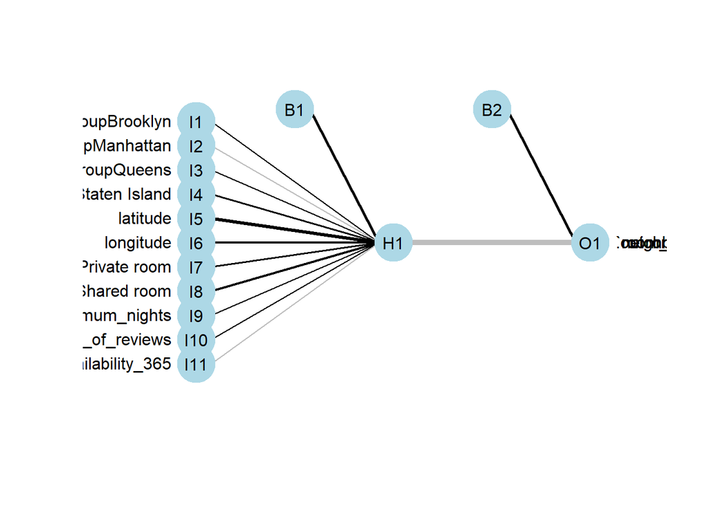

```r
plot.nnet(net)
```

We found that predicted accuracy is 82.28%, which is lower than random forest classification model.

### Text Mining

Let’s first get all the libraries ready.

```r
#if you get an error loading any libraries, install them first using install.packages:
#install.packages("tidytext")
#install.packages("textdata")
library(tidytext)
library(tidyverse)
library(topicmodels)
library(stringr)
library(gutenbergr)
library(reshape2)
library(textdata)

#Need to see documentation -- invoke help using ?:
#?tidytext
```

```r
library(wordcloud)
library(RColorBrewer)
#install.packages("wordcloud2")
library(wordcloud2)
library(tm)
```

The column “name” means the name of airbnb listings.

We now create a vector containing only the text.

```r
#View(airbnb1)
text<-airbnb1$name
#create a corpus
docs<-Corpus(VectorSource(text))
```

clean the text.

```r
docs<-docs%>%
  tm_map(removeNumbers)%>%
  tm_map(removePunctuation)%>%
  tm_map(stripWhitespace)
docs<-tm_map(docs,content_transformer(tolower))
docs<-tm_map(docs,removeWords, stopwords("english"))
```

creat a document-term-matrix

```r
dtm<- TermDocumentMatrix(docs)
matrix<-as.matrix(dtm)
words<-sort(rowSums(matrix), decreasing = TRUE)
df<-data.frame(word=names(words), freq=words)
```

generate the word cloud

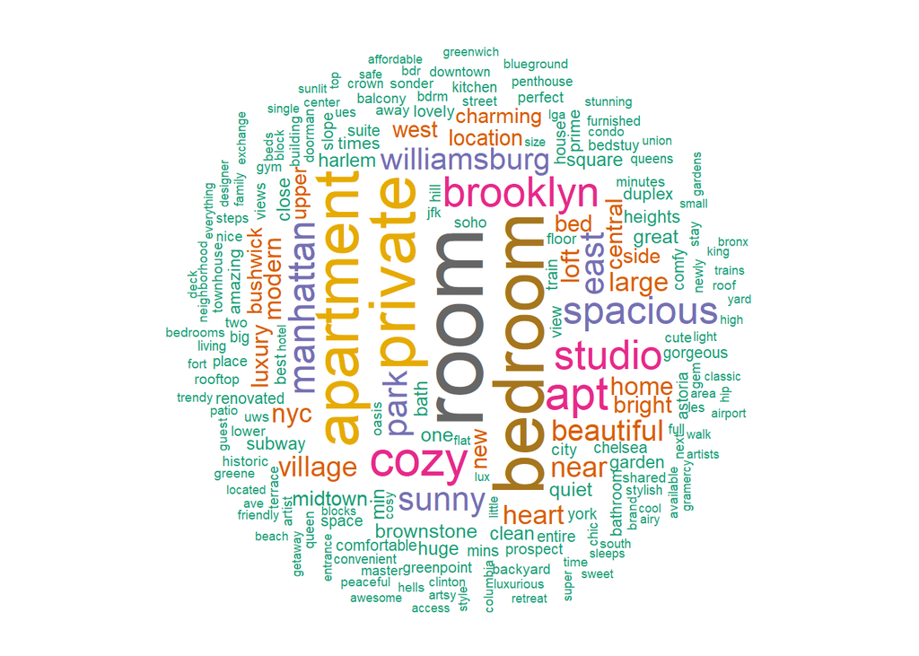

```r
set.seed(211)

wordcloud(words=df$word, freq=df$freq, min.freq=1, max.words = 200, random.order=FALSE, rot.per = 0.35,
          colors=brewer.pal(8, "Dark2")) #random.order = FALSE shows the words in decreasing frequency
```

The column of “name” in the data set not only shows the name of the Airbnb listings but also describes the features (e.g. location) and room conditions (e.g.size and room style).

As can be seen from the word cloud graph, the top 4 biggest and most frequently used words are room, bedroom, private, and apartment.

Now let’s visualize word frequency.

```r
#find the frequency for the first 20 words
head(df, 20)
```

```
##                      word  freq
## room                 room 10094
## bedroom           bedroom  8041
## private           private  7159
## apartment       apartment  6702
## cozy                 cozy  4994
## apt                   apt  4633
## brooklyn         brooklyn  4052
## studio             studio  3996
## spacious         spacious  3723
## manhattan       manhattan  3444
## park                 park  3046
## east                 east  3016
## sunny               sunny  2881
## williamsburg williamsburg  2634
## beautiful       beautiful  2478
## near                 near  2319
## village           village  2257
## nyc                   nyc  2163
## heart               heart  2049
## large               large  2045
```

plot word frequencies.

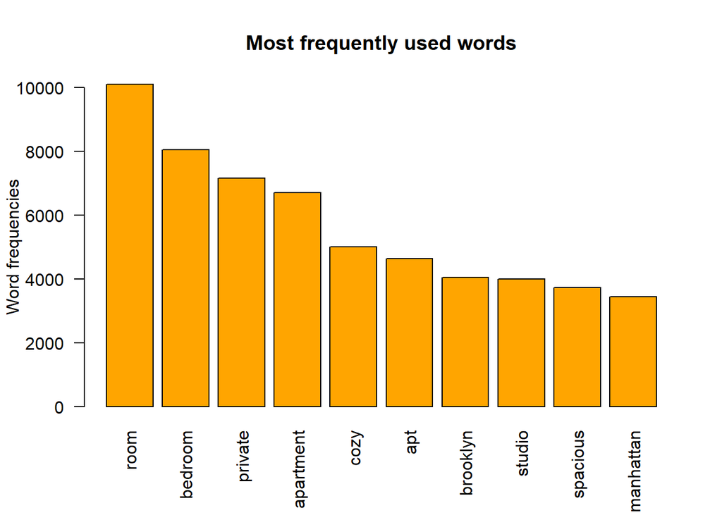

```r
barplot(df[1:10,]$freq, las = 2, names.arg = df[1:10,]$word,
        col ="orange", main ="Most frequently used words",
        ylab = "Word frequencies")
```

As we can see, “room” is used more than 10,000 times, and “bedroom” is used around 8000 times in the room listings.

### Sentiment analysis

```r
#install.packages("syuzhet")
library(syuzhet)
library(lubridate)
```

```r
library(ggplot2)
library(scales)
library(reshape2)
library(dplyr)
```

```r
t <- iconv(airbnb1$name)
#obtain sentiment scores
s <- get_nrc_sentiment(t)
head(s, 5)
```

```
##   anger anticipation disgust fear joy sadness surprise trust negative positive
## 1     0            0       0    0   1       1        0     1        0        3
## 2     0            0       0    0   0       0        0     0        0        0
## 3     0            0       0    0   0       0        0     0        0        0
## 4     0            0       0    0   0       0        0     0        0        0
## 5     0            0       0    0   0       0        0     0        0        2
```

It’s ranging from anger to trust, Negative and Positive.

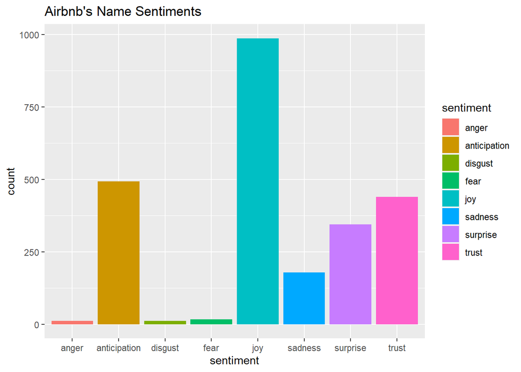

```r
#transpose
td<-data.frame(t(s))
#The function rowSums computes column sums across rows for each level of a grouping variable.
td_new <- data.frame(rowSums(td[2:2500]))
#Transformation and cleaning
names(td_new)[1] <- "count"
td_new <- cbind("sentiment" = rownames(td_new), td_new)
rownames(td_new) <- NULL
td_new2<-td_new[1:8,]
#Plot One - count of words associated with each sentiment
quickplot(sentiment, data=td_new2, weight=count, geom="bar", fill=sentiment, ylab="count")+ggtitle("Airbnb's Name Sentiments")
```

The top 3 sentiments are joy, anticipation, and trust. The name of listings are seldom express negative emotion.